# Análise Exploratória - Dados de Reclamações

Resolva os exercícios propostos abaixo.

## Leitura e análise inicial dos dados

Abra o arquivo `../data/2017-02-01_156_-_Base_de_Dados_sample-limpo.csv` que você criou no exercício de Limpeza de Dados e faça as análises e exibições iniciais do conteúdo.

Responda: Qual a média das idades das pessoas que reclamaram? Qual a idade máxima? Quantos valores únicos possuímos para a coluna `BAIRRO_ASS`?

**Dica:** A função len() pode ser usada para se obter o tamanho de listas, séries ou dataframes. Por exemplo, `len([1,3,9])` retorna 3.

```python
#importação de bibliotecas
import pandas as pd
%matplotlib inline

# lê o arquivo CSV
df = pd.read_csv('../data/2017-02-01_156_-_Base_de_Dados_sample-limpo.csv', sep=',', encoding='utf-8')

# Media de idade
df["IDADE"].mean()
```

```
48.17157005534518
```

```python
# Idade maxima
df["IDADE"].max()
```

```
96
```

```python
# Valores únicos para BAIRRO_ASS
len(df.groupby(["BAIRRO_ASS"]).size())
```

```
75
```

O primeiro passo ao se analisar dados desconhecidos é visualizar algumas linhas de dados:

```python
df.head(10)
```

|  | DATA | HORARIO | ASSUNTO | BAIRRO_ASS | SEXO | DATA_NASC | RESPOSTA_FINAL | HORA | IDADE |
| --- | --- | --- | --- | --- | --- | --- | --- | --- | --- |
| 0 | 2016-09-12 | 01:28:16 | ABORDAGEM SOCIAL DE RUA - ADULTO | centro | M | 1997-04-06 | A pessoa da solicitação já faz parte da rede d... | 1 | 19 |
| 1 | 2016-12-11 | 02:29:24 | ABORDAGEM SOCIAL DE RUA - ADULTO | centro | M | 1971-12-29 | A pessoa da solicitação já faz parte da rede d... | 2 | 45 |
| 2 | 2017-11-01 | 12:11:12 | CRM-AF/SMS | sao francisco | F | 1957-04-08 | Alendronato de sódio 70 mg e Carbonato de cálc... | 12 | 60 |
| 3 | 2016-12-14 | 10:19:29 | CRM-AF/SMS | sao francisco | F | 1938-08-18 | ALENDRONATO DE SÓDIO 70 MG E CARBONATO DE CÁL... | 10 | 78 |
| 4 | 2016-06-12 | 19:01:01 | ABORDAGEM SOCIAL DE RUA - ADULTO | centro | M | 1980-02-13 | EM ABORDAGEM REALIZADA, NÃO FOI ENCONTRADA A P... | 19 | 36 |
| 5 | 2016-09-12 | 21:52:22 | ABORDAGEM SOCIAL DE RUA - ADULTO | reboucas | M | 1978-06-20 | Abordagem realizada. Pessoa foi encaminhada pa... | 21 | 38 |
| 6 | 2016-06-12 | 23:46:39 | ABORDAGEM SOCIAL DE RUA - ADULTO | jardim botanico | M | 1982-02-02 | A pessoa da solicitação já faz parte da rede d... | 23 | 34 |
| 7 | 2016-12-21 | 15:06:16 | TRÂNSITO | jardim botanico | M | 1983-03-01 | Informamos que encaminhamos a viatura 524, che... | 15 | 33 |
| 8 | 2017-10-01 | 22:58:02 | ABORDAGEM SOCIAL DE RUA - ADULTO | jardim botanico | M | 1986-03-29 | 01 - Abordagem realizada. Pessoa foi encaminha... | 22 | 31 |
| 9 | 2017-01-21 | 07:14:40 | ABORDAGEM SOCIAL DE RUA - ADULTO | jardim botanico | F | 1983-03-29 | EM ABORDAGEM REALIZADA, NÃO FOI ENCONTRADA A P... | 7 | 34 |

## Visualização da distribuição das variáveis

Exiba histogramas para visualizar a distribuição de idades para homens e mulheres.

Responda: Existe alguma diferença na distribuição das idades entre homens e mulheres?

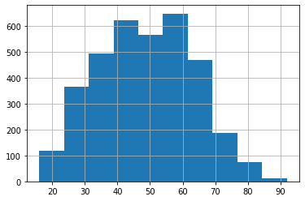

```python
# Resposta para distribuição de idades das mulheres
df_sex_fem = df[df['SEXO'] == 'F']
df_sex_fem["IDADE"].hist(bins=10)
```

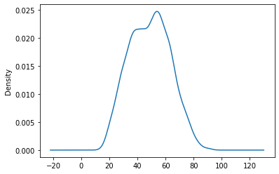

```python
df_sex_fem["IDADE"].plot.kde()
```

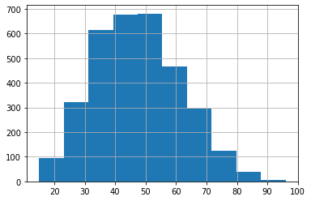

```python
# Resposta para distribuição de idades dos homens
df_sex_mas = df[df['SEXO'] == 'M']
df_sex_mas["IDADE"].hist(bins=10)
```

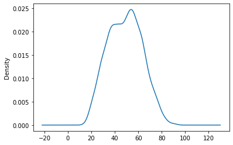

```python
df_sex_fem["IDADE"].plot.kde()
```

Exiba um BoxPlot das idades de acordo com o sexo do reclamante para ver se as diferenças ficam mais óbvias.

**Dica:** Para exibir boxplots agrupados por categoria, use o método `boxplot` como no exemplo: `df.boxplot(column='IDADE', by = 'SEXO')`.

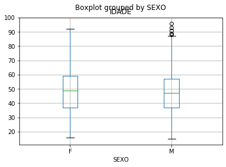

```python
# Resposta:
ax = df.boxplot(column='IDADE', by = 'SEXO')
```

## Seleção dos dados

Nesta etapa vamos filtrar apenas linhas com os tipos de relamação (assuntos) mais comuns.

- Faça uma contagem dos assuntos mais comuns (usando `groupby`). Revise o procedimento no tutorial de Manipulação e Agregação de Dados, se necessário.
- Crie uma lista contendo os assuntos com mais de 60 reclamações. Armazene a lista em uma variável para uso posterior.

**Dica:** Para criar uma lista a partir de uma coluna de valores, use o comando `list()` como no exemplo: `list(df_grouped_top['ASSUNTO'])`

```python
# Resposta:
df_grouped_top = df.groupby(['ASSUNTO']).size().reset_index(name='COUNT')
df_grouped_top = df_grouped_top[df_grouped_top['COUNT'] > 60]
list_grouped = list(df_grouped_top['ASSUNTO'])
list_grouped
```

```
['ABORDAGEM SOCIAL DE RUA - ADULTO',
 'ANIMAIS',
 'ANIMAIS DOMÉSTICOS',
 'COLETA',
 'DISQUE SOLIDARIEDADE',
 'DRENAGEM',
 'FAUNA SINANTRÓPICA',
 'FISCALIZAÇÃO DE TERRENOS BALDIOS OU EDIFICADOS',
 'ILUMINAÇÃO PÚBLICA',
 'LIMPEZA',
 'MOTORISTAS, COBRADORES E PORTEIROS',
 'OUTROS SETORES SMS',
 'POLUIÇÃO',
 'POSTO DE SAÚDE',
 'SEMÁFORO',
 'TRÂNSITO',
 'UNIDADE DE PRONTO ATENDIMENTO',
 'ÁRVORE']
```

Crie um novo DataFrame contendo apenas reclamações contidas na lista das reclamações mais comuns.

**Dica:** Para filtrar linhas que contêm valores de uma lista, use o método `isin()`. Por exemplo, `df['ASSUNTO'].isin(lista_top)` retorna uma lista de valores True/False que pode ser usada para selecionar as linhas de interesse.

```python
# Resposta:
df_reclamacao = df[df['ASSUNTO'].isin(list_grouped)]
df_reclamacao
```

|  | DATA | HORARIO | ASSUNTO | BAIRRO_ASS | SEXO | DATA_NASC | RESPOSTA_FINAL | HORA | IDADE |
| --- | --- | --- | --- | --- | --- | --- | --- | --- | --- |
| 0 | 2016-09-12 | 01:28:16 | ABORDAGEM SOCIAL DE RUA - ADULTO | centro | M | 1997-04-06 | A pessoa da solicitação já faz parte da rede d... | 1 | 19 |
| 1 | 2016-12-11 | 02:29:24 | ABORDAGEM SOCIAL DE RUA - ADULTO | centro | M | 1971-12-29 | A pessoa da solicitação já faz parte da rede d... | 2 | 45 |
| 4 | 2016-06-12 | 19:01:01 | ABORDAGEM SOCIAL DE RUA - ADULTO | centro | M | 1980-02-13 | EM ABORDAGEM REALIZADA, NÃO FOI ENCONTRADA A P... | 19 | 36 |
| 5 | 2016-09-12 | 21:52:22 | ABORDAGEM SOCIAL DE RUA - ADULTO | reboucas | M | 1978-06-20 | Abordagem realizada. Pessoa foi encaminhada pa... | 21 | 38 |
| 6 | 2016-06-12 | 23:46:39 | ABORDAGEM SOCIAL DE RUA - ADULTO | jardim botanico | M | 1982-02-02 | A pessoa da solicitação já faz parte da rede d... | 23 | 34 |
| 7 | 2016-12-21 | 15:06:16 | TRÂNSITO | jardim botanico | M | 1983-03-01 | Informamos que encaminhamos a viatura 524, che... | 15 | 33 |
| 8 | 2017-10-01 | 22:58:02 | ABORDAGEM SOCIAL DE RUA - ADULTO | jardim botanico | M | 1986-03-29 | 01 - Abordagem realizada. Pessoa foi encaminha... | 22 | 31 |
| 9 | 2017-01-21 | 07:14:40 | ABORDAGEM SOCIAL DE RUA - ADULTO | jardim botanico | F | 1983-03-29 | EM ABORDAGEM REALIZADA, NÃO FOI ENCONTRADA A P... | 7 | 34 |
| 10 | 2016-12-25 | 19:48:21 | ABORDAGEM SOCIAL DE RUA - ADULTO | jardim botanico | M | 1978-10-30 | 01 - Abordagem realizada. Pessoa foi encaminha... | 19 | 38 |
| 11 | 2016-12-21 | 00:13:12 | ABORDAGEM SOCIAL DE RUA - ADULTO | jardim botanico | M | 1982-04-11 | Abordagem realizada. Pessoa foi encaminhada pa... | 0 | 34 |
| 12 | 2016-12-23 | 09:35:22 | ABORDAGEM SOCIAL DE RUA - ADULTO | jardim botanico | M | 1974-08-09 | 07 - EM ABORDAGEM REALIZADA, NÃO FOI ENCONTRAD... | 9 | 42 |
| 13 | 2016-12-17 | 16:02:12 | ABORDAGEM SOCIAL DE RUA - ADULTO | jardim botanico | M | 1993-07-27 | A abordagem social na rua atua de acordo com a... | 16 | 23 |
| 14 | 2016-10-11 | 21:35:27 | ABORDAGEM SOCIAL DE RUA - ADULTO | jardim botanico | M | 1990-02-14 | 01 - Abordagem realizada. Pessoa foi encaminha... | 21 | 26 |
| 15 | 2016-07-11 | 19:28:42 | ABORDAGEM SOCIAL DE RUA - ADULTO | jardim botanico | M | 1977-09-27 | 01 - Abordagem realizada. Pessoa foi orientada... | 19 | 39 |
| 16 | 2016-01-11 | 22:53:12 | ABORDAGEM SOCIAL DE RUA - ADULTO | jardim botanico | M | 1983-12-11 | 01 - Abordagem realizada. Pessoa foi encaminha... | 22 | 33 |
| 17 | 2016-05-11 | 09:23:19 | ABORDAGEM SOCIAL DE RUA - ADULTO | jardim botanico | M | 1988-09-01 | A abordagem social na rua atua de acordo com a... | 9 | 28 |
| 18 | 2016-10-12 | 06:27:59 | ABORDAGEM SOCIAL DE RUA - ADULTO | jardim botanico | M | 1994-12-02 | Abordagem realizada. Pessoa foi encaminhada pa... | 6 | 22 |
| 19 | 2016-11-23 | 00:00:33 | ABORDAGEM SOCIAL DE RUA - ADULTO | jardim botanico | M | 1988-07-16 | EM ABORDAGEM REALIZADA, NÃO FOI ENCONTRADA A P... | 0 | 28 |
| 20 | 2016-07-12 | 04:54:44 | ABORDAGEM SOCIAL DE RUA - ADULTO | jardim botanico | M | 1993-04-16 | A pessoa da solicitação já faz parte da rede d... | 4 | 23 |
| 21 | 2016-02-11 | 17:23:33 | ABORDAGEM SOCIAL DE RUA - ADULTO | centro | M | 1993-06-18 | A pessoa da solicitação já faz parte da Rede d... | 17 | 23 |
| 22 | 2016-11-19 | 19:49:45 | ABORDAGEM SOCIAL DE RUA - ADULTO | centro | M | 1977-12-21 | A pessoa da solicitação já faz parte da rede d... | 19 | 39 |
| 23 | 2016-04-12 | 20:41:49 | ABORDAGEM SOCIAL DE RUA - ADULTO | centro | M | 1972-12-05 | A pessoa da solicitação já faz parte da rede d... | 20 | 44 |
| 24 | 2017-01-26 | 09:51:33 | ABORDAGEM SOCIAL DE RUA - ADULTO | centro | F | 1983-03-29 | caso repassado para cras-mz para verificação e... | 9 | 34 |
| 25 | 2016-03-11 | 20:21:36 | ABORDAGEM SOCIAL DE RUA - ADULTO | centro | M | 1956-05-31 | SOLICITAÇÃO CANCELADA PELO SOLICITANTE. | 20 | 60 |
| 26 | 2016-02-11 | 01:57:46 | ABORDAGEM SOCIAL DE RUA - ADULTO | centro | M | 1969-07-04 | abordado e encaminhado para pernoite no Boa Es... | 1 | 47 |
| 27 | 2016-05-11 | 00:48:57 | ABORDAGEM SOCIAL DE RUA - ADULTO | centro | M | 1979-09-19 | 07 - EM ABORDAGEM REALIZADA, NÃO FOI ENCONTRAD... | 0 | 37 |
| 28 | 2017-11-01 | 19:39:03 | ABORDAGEM SOCIAL DE RUA - ADULTO | centro | F | 1967-10-13 | A pessoa da solicitação já faz parte da rede d... | 19 | 50 |
| 29 | 2016-02-11 | 21:08:26 | ABORDAGEM SOCIAL DE RUA - ADULTO | alto da rua xv | M | 1961-03-14 | A pessoa da solicitação já faz parte da Rede d... | 21 | 55 |
| 30 | 2016-11-13 | 23:19:57 | TRÂNSITO | alto da rua xv | M | 1977-04-13 | Informamos que no momento do recebimento de su... | 23 | 39 |
| 32 | 2016-07-11 | 09:15:10 | ABORDAGEM SOCIAL DE RUA - ADULTO | capao da imbuia | F | 1965-03-27 | Em razão da pessoa da solicitação estar sob a ... | 9 | 51 |
| ... | ... | ... | ... | ... | ... | ... | ... | ... | ... |
| 6825 | 2016-08-12 | 15:28:03 | SEMÁFORO | centro | F | 1981-02-10 | Informamos que uma equipe de manutenção encont... | 15 | 35 |
| 6826 | 2016-12-19 | 09:13:55 | ILUMINAÇÃO PÚBLICA | ganchinho | F | 1981-07-17 | SOLICITACAO ATENDIDA | 9 | 35 |
| 6827 | 2016-12-19 | 09:13:55 | ILUMINAÇÃO PÚBLICA | ganchinho | F | 1981-07-17 | SOLICITACAO ATENDIDA | 9 | 35 |
| 6828 | 2016-12-19 | 07:59:01 | TRÂNSITO | centro | M | 1978-05-28 | Informamos que encaminhamos a viatura 433, às ... | 7 | 38 |
| 6832 | 2016-02-12 | 02:24:05 | ABORDAGEM SOCIAL DE RUA - ADULTO | hauer | M | 1983-02-12 | EM ABORDAGEM REALIZADA, NÃO FOI ENCONTRADA A P... | 2 | 33 |
| 6833 | 2016-12-17 | 00:04:46 | UNIDADE DE PRONTO ATENDIMENTO | capao raso | M | 1968-01-09 | Primeiramente agradecemos o contato e pedimos ... | 0 | 48 |
| 6834 | 2017-01-15 | 15:14:30 | ABORDAGEM SOCIAL DE RUA - ADULTO | centro | F | 1996-10-02 | EM ABORDAGEM REALIZADA, NÃO FOI ENCONTRADA A P... | 15 | 21 |
| 6835 | 2016-11-17 | 11:35:06 | MOTORISTAS, COBRADORES E PORTEIROS | pilarzinho | F | 1976-07-14 | Informamos que não foi possível darmos prosseg... | 11 | 40 |
| 6837 | 2016-06-12 | 11:39:29 | COLETA | parolin | F | 1996-07-25 | O contrato de Coleta de Vegetais, caliças e en... | 11 | 20 |
| 6839 | 2016-11-16 | 12:28:37 | ANIMAIS DOMÉSTICOS | sitio cercado | M | 1979-02-04 | Animal recolhido - Anderson - Braian | 12 | 37 |
| 6840 | 2016-11-29 | 08:52:48 | ANIMAIS DOMÉSTICOS | xaxim | M | 1986-05-22 | Animal recolhido - Anderson - Braian | 8 | 30 |
| 6842 | 2016-12-18 | 18:54:28 | MOTORISTAS, COBRADORES E PORTEIROS | tatuquara | F | 1965-08-28 | Informamos que encaminhamos a reclamação à emp... | 18 | 51 |
| 6843 | 2016-11-29 | 13:32:04 | ABORDAGEM SOCIAL DE RUA - ADULTO | centro | F | 1980-05-28 | Em resposta a solicitação de atendimento socia... | 13 | 36 |
| 6844 | 2016-12-13 | 16:56:50 | SEMÁFORO | portao | M | 1996-08-01 | Informamos que foi aberta uma ordem de serviço... | 16 | 20 |
| 6845 | 2016-10-11 | 14:53:29 | ILUMINAÇÃO PÚBLICA | jardim social | F | 1974-11-27 | Atendido | 14 | 42 |
| 6846 | 2016-11-26 | 20:48:49 | ILUMINAÇÃO PÚBLICA | cajuru | M | 1954-09-11 | Atendido | 20 | 62 |
| 6847 | 2016-10-11 | 15:27:16 | ANIMAIS | sao francisco | F | 1991-01-09 | Em caso de animal abandonado em imóvel, e muit... | 15 | 25 |
| 6848 | 2017-01-31 | 11:30:16 | TRÂNSITO | agua verde | F | 1983-10-21 | Informamos que encaminhamos a viatura 244, às ... | 11 | 34 |
| 6849 | 2016-08-12 | 14:35:37 | COLETA | cajuru | F | 1981-03-25 | O contrato de Coleta de Vegetais, caliças e en... | 14 | 35 |
| 6850 | 2016-11-19 | 12:39:21 | TRÂNSITO | reboucas | F | 1976-02-14 | Em resposta a solicitação, foi verificado junt... | 12 | 40 |
| 6853 | 2017-03-01 | 22:12:22 | ABORDAGEM SOCIAL DE RUA - ADULTO | cajuru | F | 1955-07-04 | REGISTRADO O DESAPARECIMENTO NA CENTRAL DE RES... | 22 | 62 |
| 6854 | 2016-11-22 | 08:56:08 | MOTORISTAS, COBRADORES E PORTEIROS | novo mundo | F | 1981-10-10 | Informamos que encaminhamos o elogio à empresa... | 8 | 35 |
| 6855 | 2016-10-11 | 17:44:49 | MOTORISTAS, COBRADORES E PORTEIROS | bacacheri | M | 1946-12-30 | Informamos que não foi possível localizar corr... | 17 | 70 |
| 6856 | 2016-02-12 | 16:50:58 | TRÂNSITO | centro | M | 1974-09-26 | Informamos que o agente citado foi convocado e... | 16 | 42 |
| 6857 | 2017-01-31 | 21:49:05 | TRÂNSITO | centro | M | 1983-04-21 | INFORMAMOS QUE ENVIAMOS A VIATURA 243 CHEGANDO... | 21 | 34 |
| 6858 | 2017-01-27 | 19:24:18 | ABORDAGEM SOCIAL DE RUA - ADULTO | jardim botanico | M | 1988-11-05 | EM ABORDAGEM REALIZADA, NÃO FOI ENCONTRADA A P... | 19 | 29 |
| 6859 | 2016-04-11 | 03:26:52 | ABORDAGEM SOCIAL DE RUA - ADULTO | jardim botanico | M | 1983-01-19 | 01 - Abordagem realizada sendo o homem encamin... | 3 | 33 |
| 6861 | 2016-11-28 | 13:04:25 | DRENAGEM | cidade industrial | M | 1968-04-14 | SEM POSSIBILIDADE DE ATENDIMENTO FACE SUSPENSÃ... | 13 | 48 |
| 6862 | 2016-12-22 | 10:11:15 | TRÂNSITO | juveve | M | 1989-05-18 | Informamos que encaminhamos a viatura 430, às ... | 10 | 27 |
| 6865 | 2017-11-01 | 20:10:14 | ABORDAGEM SOCIAL DE RUA - ADULTO | jardim botanico | M | 1987-10-19 | Em atendimento a solicitação encontrava-se um ... | 20 | 30 |

5655 rows × 9 columns

## Análise de similaridades entre reclamações de bairros

Queremos agora identificar bairros com problemas similares. Use o método `crosstab()` para gerar um novo DataFrame com os bairros nas colunas e os assuntos (os mais comuns, filtrados acima) nas linhas.

```python
# Resposta:
df_cross = pd.crosstab(df_reclamacao.ASSUNTO, df_reclamacao.BAIRRO_ASS)
df_cross.head(10)
```

| BAIRRO_ASS ASSUNTO | abranches | agua verde | ahu | alto boqueirao | alto da gloria | alto da rua xv | atuba | augusta | bacacheri | bairro alto | ... | sitio cercado | taboao | taruma | tatuquara | tingui | uberaba | umbara | vila izabel | vista alegre | xaxim |
| --- | --- | --- | --- | --- | --- | --- | --- | --- | --- | --- | --- | --- | --- | --- | --- | --- | --- | --- | --- | --- | --- |
| ABORDAGEM SOCIAL DE RUA - ADULTO | 2 | 8 | 4 | 3 | 5 | 6 | 2 | 0 | 7 | 2 | ... | 4 | 0 | 0 | 1 | 1 | 0 | 0 | 0 | 1 | 0 |
| ANIMAIS | 0 | 0 | 1 | 7 | 1 | 0 | 0 | 2 | 1 | 2 | ... | 7 | 0 | 0 | 5 | 1 | 8 | 3 | 1 | 3 | 2 |
| ANIMAIS DOMÉSTICOS | 1 | 1 | 0 | 4 | 0 | 0 | 0 | 0 | 3 | 5 | ... | 7 | 0 | 0 | 4 | 0 | 10 | 1 | 0 | 0 | 7 |
| COLETA | 15 | 41 | 17 | 31 | 4 | 13 | 7 | 4 | 34 | 86 | ... | 60 | 1 | 28 | 19 | 13 | 47 | 5 | 7 | 26 | 47 |
| DISQUE SOLIDARIEDADE | 1 | 4 | 2 | 5 | 0 | 4 | 1 | 0 | 2 | 4 | ... | 9 | 1 | 0 | 2 | 2 | 3 | 2 | 1 | 4 | 6 |
| DRENAGEM | 0 | 1 | 0 | 5 | 0 | 0 | 2 | 0 | 2 | 0 | ... | 5 | 0 | 1 | 2 | 2 | 5 | 2 | 1 | 1 | 3 |
| FAUNA SINANTRÓPICA | 1 | 2 | 0 | 2 | 2 | 1 | 0 | 0 | 2 | 1 | ... | 6 | 0 | 0 | 1 | 1 | 3 | 1 | 0 | 1 | 4 |
| FISCALIZAÇÃO DE TERRENOS BALDIOS OU EDIFICADOS | 1 | 13 | 1 | 2 | 0 | 2 | 1 | 1 | 0 | 0 | ... | 7 | 0 | 0 | 3 | 0 | 9 | 2 | 0 | 2 | 4 |
| ILUMINAÇÃO PÚBLICA | 12 | 22 | 9 | 29 | 5 | 11 | 12 | 2 | 21 | 26 | ... | 45 | 3 | 14 | 22 | 4 | 38 | 7 | 4 | 8 | 36 |
| LIMPEZA | 0 | 4 | 2 | 1 | 0 | 1 | 0 | 0 | 1 | 0 | ... | 2 | 0 | 0 | 0 | 0 | 3 | 0 | 0 | 1 | 0 |

10 rows × 75 columns

Usando o DataFrame obtido anteriormente, gere a matriz de correlações entre bairros (método `corr()`).

```python
# Resposta:
df_corr = df_cross.corr()
df_corr
```

| BAIRRO_ASS | abranches | agua verde | ahu | alto boqueirao | alto da gloria | alto da rua xv | atuba | augusta | bacacheri | bairro alto | ... | sitio cercado | taboao | taruma | tatuquara | tingui | uberaba | umbara | vila izabel | vista alegre | xaxim |
| --- | --- | --- | --- | --- | --- | --- | --- | --- | --- | --- | --- | --- | --- | --- | --- | --- | --- | --- | --- | --- | --- |
| abranches | 1.000000 | 0.643055 | 0.884902 | 0.970722 | 1.230240e-01 | 0.791709 | 0.794544 | 7.774655e-01 | 0.874166 | 0.903948 | ... | 0.963485 | 0.465605 | 0.907070 | 0.883269 | 0.844186 | 0.954435 | 0.678211 | 0.624121 | 0.854907 | 0.975221 |
| agua verde | 0.643055 | 1.000000 | 0.858102 | 0.623982 | 7.412255e-01 | 0.872836 | 0.791846 | 4.578731e-01 | 0.797828 | 0.637879 | ... | 0.587818 | 0.204879 | 0.812256 | 0.517301 | 0.634941 | 0.653743 | 0.781724 | 0.907642 | 0.687336 | 0.670143 |
| ahu | 0.884902 | 0.858102 | 1.000000 | 0.848473 | 3.899063e-01 | 0.914807 | 0.807990 | 7.148652e-01 | 0.935760 | 0.886528 | ... | 0.852842 | 0.358148 | 0.955636 | 0.693846 | 0.852803 | 0.870747 | 0.737892 | 0.818051 | 0.917330 | 0.860442 |
| alto boqueirao | 0.970722 | 0.623982 | 0.848473 | 1.000000 | 1.568730e-01 | 0.759529 | 0.817464 | 7.744076e-01 | 0.831386 | 0.854039 | ... | 0.934172 | 0.446280 | 0.876565 | 0.902115 | 0.832988 | 0.952150 | 0.756346 | 0.648789 | 0.819032 | 0.972161 |
| alto da gloria | 0.123024 | 0.741225 | 0.389906 | 0.156873 | 1.000000e+00 | 0.489287 | 0.515642 | -9.896625e-02 | 0.419315 | 0.067272 | ... | 0.074968 | -0.087167 | 0.303575 | 0.126778 | 0.150834 | 0.118885 | 0.521474 | 0.684358 | 0.111794 | 0.177159 |
| alto da rua xv | 0.791709 | 0.872836 | 0.914807 | 0.759529 | 4.892866e-01 | 1.000000 | 0.861303 | 5.306360e-01 | 0.846835 | 0.713888 | ... | 0.734772 | 0.406098 | 0.861454 | 0.629540 | 0.689281 | 0.750817 | 0.736560 | 0.774724 | 0.750563 | 0.752232 |
| atuba | 0.794544 | 0.791846 | 0.807990 | 0.817464 | 5.156417e-01 | 0.861303 | 1.000000 | 4.992519e-01 | 0.800748 | 0.578643 | ... | 0.740967 | 0.570124 | 0.784540 | 0.755318 | 0.573910 | 0.788739 | 0.889417 | 0.776734 | 0.595236 | 0.782727 |
| augusta | 0.777465 | 0.457873 | 0.714865 | 0.774408 | -9.896625e-02 | 0.530636 | 0.499252 | 1.000000e+00 | 0.661465 | 0.830207 | ... | 0.818616 | 0.385337 | 0.781756 | 0.729363 | 0.702112 | 0.832935 | 0.585468 | 0.439727 | 0.836092 | 0.748687 |
| bacacheri | 0.874166 | 0.797828 | 0.935760 | 0.831386 | 4.193150e-01 | 0.846835 | 0.800748 | 6.614647e-01 | 1.000000 | 0.859777 | ... | 0.888116 | 0.334601 | 0.931718 | 0.706800 | 0.802101 | 0.851041 | 0.702908 | 0.786965 | 0.856548 | 0.851213 |
| bairro alto | 0.903948 | 0.637879 | 0.886528 | 0.854039 | 6.727222e-02 | 0.713888 | 0.578643 | 8.302073e-01 | 0.859777 | 1.000000 | ... | 0.910126 | 0.285449 | 0.933372 | 0.734822 | 0.913296 | 0.888634 | 0.542919 | 0.633023 | 0.964508 | 0.897782 |
| barreirinha | 0.915815 | 0.512614 | 0.792047 | 0.897237 | -1.428142e-02 | 0.745147 | 0.782158 | 7.585313e-01 | 0.772182 | 0.800084 | ... | 0.920390 | 0.721051 | 0.830869 | 0.851825 | 0.698271 | 0.897028 | 0.681754 | 0.547426 | 0.774076 | 0.879608 |
| batel | 0.142382 | 0.784086 | 0.420994 | 0.177024 | 9.795160e-01 | 0.520838 | 0.526349 | -5.936789e-02 | 0.402806 | 0.112680 | ... | 0.073046 | -0.035015 | 0.346663 | 0.146435 | 0.189534 | 0.143059 | 0.548753 | 0.736252 | 0.152381 | 0.212333 |
| bigorrilho | 0.429061 | 0.891026 | 0.686083 | 0.431543 | 8.254190e-01 | 0.846231 | 0.721637 | 1.591324e-01 | 0.618621 | 0.375615 | ... | 0.354433 | 0.193234 | 0.597272 | 0.345341 | 0.409565 | 0.394154 | 0.650798 | 0.801989 | 0.427123 | 0.441178 |
| boa vista | 0.910496 | 0.697960 | 0.945146 | 0.859270 | 1.036845e-01 | 0.807810 | 0.675080 | 8.254409e-01 | 0.891005 | 0.965680 | ... | 0.909988 | 0.367008 | 0.954939 | 0.698475 | 0.900100 | 0.907859 | 0.623767 | 0.665413 | 0.981339 | 0.880530 |
| bom retiro | 0.728421 | 0.871694 | 0.922838 | 0.681477 | 4.870610e-01 | 0.800680 | 0.637827 | 6.238503e-01 | 0.852985 | 0.848775 | ... | 0.708498 | 0.219406 | 0.908306 | 0.523955 | 0.833887 | 0.719528 | 0.604264 | 0.811173 | 0.869328 | 0.740403 |
| boqueirao | 0.902368 | 0.687015 | 0.922535 | 0.859317 | 1.022495e-01 | 0.775793 | 0.648186 | 8.709485e-01 | 0.879996 | 0.982275 | ... | 0.912148 | 0.371180 | 0.960996 | 0.730004 | 0.892711 | 0.906392 | 0.630485 | 0.676717 | 0.979910 | 0.884666 |
| butiatuvinha | 0.828907 | 0.569184 | 0.811249 | 0.809132 | 5.692774e-02 | 0.596820 | 0.458778 | 8.388680e-01 | 0.767265 | 0.957686 | ... | 0.823279 | 0.189990 | 0.860111 | 0.661867 | 0.934159 | 0.799744 | 0.474622 | 0.580678 | 0.923508 | 0.848103 |
| cabral | 0.376865 | 0.825814 | 0.635861 | 0.379594 | 7.739826e-01 | 0.670973 | 0.622665 | 3.387485e-01 | 0.578387 | 0.400459 | ... | 0.319758 | 0.316197 | 0.617362 | 0.301954 | 0.436333 | 0.364947 | 0.611210 | 0.757320 | 0.428375 | 0.404385 |
| cachoeira | 0.954405 | 0.527836 | 0.823394 | 0.919115 | -1.407751e-02 | 0.746215 | 0.780677 | 7.776093e-01 | 0.826188 | 0.838246 | ... | 0.941834 | 0.595108 | 0.858545 | 0.852123 | 0.727526 | 0.939118 | 0.645013 | 0.519226 | 0.794557 | 0.899490 |
| cajuru | 0.976731 | 0.545761 | 0.833334 | 0.938669 | 3.452699e-03 | 0.693310 | 0.701430 | 8.107224e-01 | 0.847244 | 0.924602 | ... | 0.976580 | 0.426626 | 0.875600 | 0.891285 | 0.820342 | 0.941310 | 0.600824 | 0.562270 | 0.860007 | 0.946695 |
| campina do siqueira | 0.504533 | 0.706063 | 0.615472 | 0.485636 | 7.440079e-01 | 0.624748 | 0.625439 | 2.945218e-01 | 0.769863 | 0.453996 | ... | 0.538490 | 0.057707 | 0.580535 | 0.495958 | 0.409472 | 0.450894 | 0.525637 | 0.671975 | 0.423585 | 0.488387 |
| campo comprido | 0.586123 | 0.839517 | 0.742190 | 0.593394 | 6.324930e-01 | 0.873876 | 0.810502 | 3.479433e-01 | 0.683845 | 0.510545 | ... | 0.539462 | 0.482455 | 0.747346 | 0.494495 | 0.513211 | 0.577320 | 0.731127 | 0.771985 | 0.544805 | 0.600438 |
| campo de santana | 0.719228 | 0.258162 | 0.457441 | 0.752362 | -3.581421e-02 | 0.463631 | 0.720276 | 5.190647e-01 | 0.480532 | 0.432719 | ... | 0.712012 | 0.639887 | 0.486067 | 0.872931 | 0.306727 | 0.712674 | 0.605525 | 0.316808 | 0.360896 | 0.680995 |
| capao da imbuia | 0.955744 | 0.631410 | 0.856304 | 0.926682 | 9.847964e-02 | 0.760956 | 0.727252 | 8.206363e-01 | 0.836913 | 0.911712 | ... | 0.960965 | 0.361126 | 0.879895 | 0.921045 | 0.780497 | 0.941192 | 0.652610 | 0.614438 | 0.860173 | 0.920175 |
| capao raso | 0.890091 | 0.767300 | 0.908112 | 0.865718 | 3.712062e-01 | 0.828368 | 0.838330 | 7.274754e-01 | 0.972819 | 0.837945 | ... | 0.919871 | 0.459245 | 0.928219 | 0.755488 | 0.785184 | 0.885542 | 0.768276 | 0.750735 | 0.845334 | 0.872750 |
| cascatinha | 0.885406 | 0.593581 | 0.885962 | 0.831313 | -8.606665e-03 | 0.705338 | 0.589681 | 8.116794e-01 | 0.841277 | 0.954872 | ... | 0.895742 | 0.335111 | 0.915112 | 0.678889 | 0.868735 | 0.890596 | 0.526627 | 0.581842 | 0.951435 | 0.856303 |
| caximba | 0.314143 | -0.023514 | 0.113592 | 0.393580 | -9.797159e-02 | 0.201336 | 0.307957 | 3.434577e-17 | 0.084275 | 0.064594 | ... | 0.221756 | 0.389249 | 0.084234 | 0.240053 | 0.266398 | 0.201257 | 0.231346 | 0.040121 | 0.075473 | 0.362222 |
| centro | 0.137770 | 0.609453 | 0.392261 | 0.112547 | 7.770017e-01 | 0.555409 | 0.504118 | -9.842681e-02 | 0.334914 | 0.025916 | ... | 0.019481 | 0.124619 | 0.243295 | 0.077967 | 0.100008 | 0.043944 | 0.342930 | 0.482141 | 0.050485 | 0.092575 |
| centro civico | 0.040548 | 0.699540 | 0.314338 | 0.090377 | 9.732607e-01 | 0.445072 | 0.472730 | -1.478252e-01 | 0.292092 | -0.014633 | ... | -0.025656 | -0.025697 | 0.234023 | 0.074699 | 0.082606 | 0.042335 | 0.499721 | 0.643406 | 0.033217 | 0.109492 |
| cidade industrial | 0.968973 | 0.636181 | 0.841986 | 0.973482 | 1.440895e-01 | 0.753626 | 0.845250 | 7.563246e-01 | 0.828760 | 0.845377 | ... | 0.942462 | 0.486116 | 0.876011 | 0.926186 | 0.783250 | 0.959615 | 0.760813 | 0.655998 | 0.803259 | 0.958388 |
| ... | ... | ... | ... | ... | ... | ... | ... | ... | ... | ... | ... | ... | ... | ... | ... | ... | ... | ... | ... | ... | ... |
| mossungue | 0.908748 | 0.828035 | 0.957424 | 0.893410 | 3.661019e-01 | 0.878395 | 0.830092 | 7.167942e-01 | 0.934348 | 0.895049 | ... | 0.895802 | 0.430453 | 0.970317 | 0.754858 | 0.851516 | 0.921045 | 0.790639 | 0.811271 | 0.904176 | 0.919161 |
| novo mundo | 0.854421 | 0.746401 | 0.911117 | 0.808414 | 2.480402e-01 | 0.755449 | 0.605914 | 7.631630e-01 | 0.865176 | 0.964098 | ... | 0.844659 | 0.236690 | 0.928815 | 0.685265 | 0.903497 | 0.824980 | 0.597269 | 0.727361 | 0.951850 | 0.864375 |
| orleans | 0.939228 | 0.758001 | 0.905228 | 0.940999 | 3.026930e-01 | 0.852044 | 0.898696 | 6.954838e-01 | 0.903310 | 0.821545 | ... | 0.897558 | 0.509018 | 0.920286 | 0.810778 | 0.797154 | 0.927556 | 0.821307 | 0.782495 | 0.818246 | 0.944502 |
| parolin | 0.875792 | 0.718012 | 0.925833 | 0.805686 | 1.562498e-01 | 0.793654 | 0.666579 | 7.665282e-01 | 0.861756 | 0.909857 | ... | 0.860048 | 0.321193 | 0.908013 | 0.663004 | 0.830696 | 0.895953 | 0.621551 | 0.658061 | 0.928057 | 0.839807 |
| pilarzinho | 0.975035 | 0.643797 | 0.908692 | 0.943970 | 8.086884e-02 | 0.790624 | 0.749713 | 8.291270e-01 | 0.887930 | 0.947861 | ... | 0.973032 | 0.480938 | 0.944075 | 0.835452 | 0.868928 | 0.958231 | 0.680235 | 0.643451 | 0.927939 | 0.952996 |
| pinheirinho | 0.926880 | 0.644992 | 0.881106 | 0.888247 | 1.300512e-01 | 0.739923 | 0.665251 | 8.307508e-01 | 0.838670 | 0.953784 | ... | 0.919569 | 0.442762 | 0.914564 | 0.829358 | 0.861988 | 0.895535 | 0.612849 | 0.654280 | 0.900810 | 0.915528 |
| portao | 0.737056 | 0.947406 | 0.928919 | 0.689343 | 5.544392e-01 | 0.856637 | 0.714886 | 6.286155e-01 | 0.859388 | 0.808958 | ... | 0.701855 | 0.223696 | 0.898643 | 0.552001 | 0.786645 | 0.740241 | 0.712087 | 0.861083 | 0.849220 | 0.750032 |
| prado velho | 0.147431 | 0.753371 | 0.401024 | 0.190035 | 9.555989e-01 | 0.494354 | 0.521077 | -9.694584e-02 | 0.389379 | 0.105751 | ... | 0.088751 | -0.032020 | 0.326249 | 0.159416 | 0.182618 | 0.169615 | 0.582611 | 0.739832 | 0.155213 | 0.235483 |
| reboucas | 0.423733 | 0.628627 | 0.536333 | 0.397686 | 6.587259e-01 | 0.651790 | 0.615919 | 1.104036e-01 | 0.485589 | 0.262972 | ... | 0.277695 | 0.175313 | 0.400877 | 0.366808 | 0.330860 | 0.274242 | 0.406545 | 0.505653 | 0.227748 | 0.374207 |
| riviera | 0.740447 | 0.558149 | 0.800853 | 0.668186 | 4.424174e-18 | 0.585653 | 0.362541 | 7.669650e-01 | 0.758695 | 0.949958 | ... | 0.767568 | 0.126660 | 0.845121 | 0.508542 | 0.879981 | 0.738348 | 0.363189 | 0.543960 | 0.941415 | 0.733961 |
| santa candida | 0.968889 | 0.639815 | 0.899916 | 0.934110 | 6.276249e-02 | 0.775934 | 0.732743 | 8.280907e-01 | 0.881049 | 0.957423 | ... | 0.971485 | 0.477723 | 0.946699 | 0.832734 | 0.867723 | 0.960251 | 0.664527 | 0.640746 | 0.929669 | 0.952567 |
| santa felicidade | 0.945630 | 0.592441 | 0.877200 | 0.913642 | 8.943307e-03 | 0.752852 | 0.702516 | 8.702030e-01 | 0.841673 | 0.945101 | ... | 0.949031 | 0.552728 | 0.933462 | 0.814273 | 0.857436 | 0.931454 | 0.632522 | 0.595817 | 0.914524 | 0.919659 |
| santa quiteria | 0.928100 | 0.741585 | 0.924572 | 0.892917 | 2.043178e-01 | 0.780943 | 0.696857 | 8.239029e-01 | 0.901351 | 0.978218 | ... | 0.923916 | 0.330327 | 0.962324 | 0.797149 | 0.892216 | 0.916950 | 0.671232 | 0.747486 | 0.950559 | 0.933418 |
| santo inacio | 0.937139 | 0.586927 | 0.888238 | 0.895670 | -7.384719e-03 | 0.755208 | 0.682452 | 8.058804e-01 | 0.869760 | 0.943467 | ... | 0.942585 | 0.418977 | 0.922224 | 0.745708 | 0.871473 | 0.935722 | 0.612899 | 0.590613 | 0.939802 | 0.903516 |
| sao braz | 0.919956 | 0.688921 | 0.921434 | 0.868612 | 1.152519e-01 | 0.778350 | 0.648060 | 8.169281e-01 | 0.884561 | 0.986298 | ... | 0.930078 | 0.315750 | 0.945987 | 0.760644 | 0.889979 | 0.909398 | 0.610577 | 0.676784 | 0.973987 | 0.903346 |
| sao francisco | 0.348210 | 0.754905 | 0.499563 | 0.371846 | 8.793168e-01 | 0.604504 | 0.690533 | 5.705974e-02 | 0.480895 | 0.192946 | ... | 0.254696 | 0.130129 | 0.398123 | 0.432820 | 0.207989 | 0.302290 | 0.611285 | 0.720347 | 0.175458 | 0.369841 |
| sao joao | 0.930083 | 0.575095 | 0.849812 | 0.886034 | -1.377724e-02 | 0.738706 | 0.711282 | 8.352691e-01 | 0.842854 | 0.899910 | ... | 0.927095 | 0.536434 | 0.916240 | 0.754688 | 0.815312 | 0.920641 | 0.644839 | 0.560809 | 0.891526 | 0.897283 |
| sao lourenco | 0.820047 | 0.742522 | 0.818716 | 0.808659 | 3.955628e-01 | 0.694366 | 0.654737 | 6.518317e-01 | 0.808458 | 0.857758 | ... | 0.815472 | 0.153781 | 0.837289 | 0.804371 | 0.788729 | 0.792109 | 0.625971 | 0.739686 | 0.795124 | 0.844546 |
| sao miguel | 0.348648 | 0.105815 | 0.197566 | 0.344973 | -4.979144e-02 | 0.289400 | 0.528490 | 2.795085e-01 | 0.206538 | 0.096124 | ... | 0.318401 | 0.923186 | 0.283019 | 0.367695 | 0.076584 | 0.318216 | 0.356165 | 0.079295 | 0.059667 | 0.305243 |
| seminario | 0.518521 | 0.974131 | 0.763279 | 0.518889 | 8.249213e-01 | 0.762363 | 0.707637 | 3.811820e-01 | 0.708430 | 0.536075 | ... | 0.470191 | 0.118032 | 0.716154 | 0.423823 | 0.560968 | 0.541963 | 0.758941 | 0.891306 | 0.597569 | 0.572734 |
| sitio cercado | 0.963485 | 0.587818 | 0.852842 | 0.934172 | 7.496772e-02 | 0.734772 | 0.740967 | 8.186158e-01 | 0.888116 | 0.910126 | ... | 1.000000 | 0.449364 | 0.896885 | 0.886994 | 0.796490 | 0.960357 | 0.662525 | 0.592859 | 0.871290 | 0.929910 |
| taboao | 0.465605 | 0.204879 | 0.358148 | 0.446280 | -8.716661e-02 | 0.406098 | 0.570124 | 3.853373e-01 | 0.334601 | 0.285449 | ... | 0.449364 | 1.000000 | 0.426244 | 0.429241 | 0.254525 | 0.433171 | 0.440778 | 0.257679 | 0.274194 | 0.441577 |
| taruma | 0.907070 | 0.812256 | 0.955636 | 0.876565 | 3.035751e-01 | 0.861454 | 0.784540 | 7.817557e-01 | 0.931718 | 0.933372 | ... | 0.896885 | 0.426244 | 1.000000 | 0.732600 | 0.882289 | 0.906221 | 0.728206 | 0.780455 | 0.931094 | 0.905702 |
| tatuquara | 0.883269 | 0.517301 | 0.693846 | 0.902115 | 1.267785e-01 | 0.629540 | 0.755318 | 7.293634e-01 | 0.706800 | 0.734822 | ... | 0.886994 | 0.429241 | 0.732600 | 1.000000 | 0.584084 | 0.890315 | 0.703325 | 0.545508 | 0.649683 | 0.866388 |
| tingui | 0.844186 | 0.634941 | 0.852803 | 0.832988 | 1.508342e-01 | 0.689281 | 0.573910 | 7.021124e-01 | 0.802101 | 0.913296 | ... | 0.796490 | 0.254525 | 0.882289 | 0.584084 | 1.000000 | 0.787015 | 0.529311 | 0.643710 | 0.907811 | 0.872891 |
| uberaba | 0.954435 | 0.653743 | 0.870747 | 0.952150 | 1.188850e-01 | 0.750817 | 0.788739 | 8.329350e-01 | 0.851041 | 0.888634 | ... | 0.960357 | 0.433171 | 0.906221 | 0.890315 | 0.787015 | 1.000000 | 0.764711 | 0.654870 | 0.871909 | 0.942704 |
| umbara | 0.678211 | 0.781724 | 0.737892 | 0.756346 | 5.214739e-01 | 0.736560 | 0.889417 | 5.854677e-01 | 0.702908 | 0.542919 | ... | 0.662525 | 0.440778 | 0.728206 | 0.703325 | 0.529311 | 0.764711 | 1.000000 | 0.829250 | 0.620305 | 0.720214 |
| vila izabel | 0.624121 | 0.907642 | 0.818051 | 0.648789 | 6.843583e-01 | 0.774724 | 0.776734 | 4.397274e-01 | 0.786965 | 0.633023 | ... | 0.592859 | 0.257679 | 0.780455 | 0.545508 | 0.643710 | 0.654870 | 0.829250 | 1.000000 | 0.681306 | 0.690296 |
| vista alegre | 0.854907 | 0.687336 | 0.917330 | 0.819032 | 1.117937e-01 | 0.750563 | 0.595236 | 8.360925e-01 | 0.856548 | 0.964508 | ... | 0.871290 | 0.274194 | 0.931094 | 0.649683 | 0.907811 | 0.871909 | 0.620305 | 0.681306 | 1.000000 | 0.847180 |
| xaxim | 0.975221 | 0.670143 | 0.860442 | 0.972161 | 1.771589e-01 | 0.752232 | 0.782727 | 7.486871e-01 | 0.851213 | 0.897782 | ... | 0.929910 | 0.441577 | 0.905702 | 0.866388 | 0.872891 | 0.942704 | 0.720214 | 0.690296 | 0.847180 | 1.000000 |

75 rows × 75 columns

Use um Heatmap para exibir as correlações com cores.

```python
# Resposta:
df_corr = df_corr.style.background_gradient(cmap="RdBu")
df_corr
```

| BAIRRO_ASS | abranches | agua verde | ahu | alto boqueirao | alto da gloria | alto da rua xv | atuba | augusta | bacacheri | bairro alto | barreirinha | batel | bigorrilho | boa vista | bom retiro | boqueirao | butiatuvinha | cabral | cachoeira | cajuru | campina do siqueira | campo comprido | campo de santana | capao da imbuia | capao raso | cascatinha | caximba | centro | centro civico | … |
| --- | --- | --- | --- | --- | --- | --- | --- | --- | --- | --- | --- | --- | --- | --- | --- | --- | --- | --- | --- | --- | --- | --- | --- | --- | --- | --- | --- | --- | --- | --- |
| abranches | 1 | 0.643055 | 0.884902 | 0.970722 | 0.123024 | 0.791709 | 0.794544 | 0.777465 | 0.874166 | 0.903948 | 0.915815 | 0.142382 | 0.429061 | 0.910496 | 0.728421 | 0.902368 | 0.828907 | 0.376865 | 0.954405 | 0.976731 | 0.504533 | 0.586123 | 0.719228 | 0.955744 | 0.890091 | 0.885406 | 0.314143 | 0.13777 | 0.0405475 | … |
| agua verde | 0.643055 | 1 | 0.858102 | 0.623982 | 0.741225 | 0.872836 | 0.791846 | 0.457873 | 0.797828 | 0.637879 | 0.512614 | 0.784086 | 0.891026 | 0.69796 | 0.871694 | 0.687015 | 0.569184 | 0.825814 | 0.527836 | 0.545761 | 0.706063 | 0.839517 | 0.258162 | 0.63141 | 0.7673 | 0.593581 | -0.0235137 | 0.609453 | 0.69954 | … |
| ahu | 0.884902 | 0.858102 | 1 | 0.848473 | 0.389906 | 0.914807 | 0.80799 | 0.714865 | 0.93576 | 0.886528 | 0.792047 | 0.420994 | 0.686083 | 0.945146 | 0.922838 | 0.922535 | 0.811249 | 0.635861 | 0.823394 | 0.833334 | 0.615472 | 0.74219 | 0.457441 | 0.856304 | 0.908112 | 0.885962 | 0.113592 | 0.392261 | 0.314338 | … |
| alto boqueirao | 0.970722 | 0.623982 | 0.848473 | 1 | 0.156873 | 0.759529 | 0.817464 | 0.774408 | 0.831386 | 0.854039 | 0.897237 | 0.177024 | 0.431543 | 0.85927 | 0.681477 | 0.859317 | 0.809132 | 0.379594 | 0.919115 | 0.938669 | 0.485636 | 0.593394 | 0.752362 | 0.926682 | 0.865718 | 0.831313 | 0.39358 | 0.112547 | 0.0903766 | … |
| alto da gloria | 0.123024 | 0.741225 | 0.389906 | 0.156873 | 1 | 0.489287 | 0.515642 | -0.0989663 | 0.419315 | 0.0672722 | -0.0142814 | 0.979516 | 0.825419 | 0.103684 | 0.487061 | 0.102249 | 0.0569277 | 0.773983 | -0.0140775 | 0.0034527 | 0.744008 | 0.632493 | -0.0358142 | 0.0984796 | 0.371206 | -0.00860667 | -0.0979716 | 0.777002 | 0.973261 | … |
| alto da rua xv | 0.791709 | 0.872836 | 0.914807 | 0.759529 | 0.489287 | 1 | 0.861303 | 0.530636 | 0.846835 | 0.713888 | 0.745147 | 0.520838 | 0.846231 | 0.80781 | 0.80068 | 0.775793 | 0.59682 | 0.670973 | 0.746215 | 0.69331 | 0.624748 | 0.873876 | 0.463631 | 0.760956 | 0.828368 | 0.705338 | 0.201336 | 0.555409 | 0.445072 | … |
| atuba | 0.794544 | 0.791846 | 0.80799 | 0.817464 | 0.515642 | 0.861303 | 1 | 0.499252 | 0.800748 | 0.578643 | 0.782158 | 0.526349 | 0.721637 | 0.67508 | 0.637827 | 0.648186 | 0.458778 | 0.622665 | 0.780677 | 0.70143 | 0.625439 | 0.810502 | 0.720276 | 0.727252 | 0.83833 | 0.589681 | 0.307957 | 0.504118 | 0.47273 | … |
| augusta | 0.777465 | 0.457873 | 0.714865 | 0.774408 | -0.0989663 | 0.530636 | 0.499252 | 1 | 0.661465 | 0.830207 | 0.758531 | -0.0593679 | 0.159132 | 0.825441 | 0.62385 | 0.870948 | 0.838868 | 0.338748 | 0.777609 | 0.810722 | 0.294522 | 0.347943 | 0.519065 | 0.820636 | 0.727475 | 0.811679 | 3.43458e-17 | -0.0984268 | -0.147825 | … |
| bacacheri | 0.874166 | 0.797828 | 0.93576 | 0.831386 | 0.419315 | 0.846835 | 0.800748 | 0.661465 | 1 | 0.859777 | 0.772182 | 0.402806 | 0.618621 | 0.891005 | 0.852985 | 0.879996 | 0.767265 | 0.578387 | 0.826188 | 0.847244 | 0.769863 | 0.683845 | 0.480532 | 0.836913 | 0.972819 | 0.841277 | 0.084275 | 0.334914 | 0.292092 | … |
| bairro alto | 0.903948 | 0.637879 | 0.886528 | 0.854039 | 0.0672722 | 0.713888 | 0.578643 | 0.830207 | 0.859777 | 1 | 0.800084 | 0.11268 | 0.375615 | 0.96568 | 0.848775 | 0.982275 | 0.957686 | 0.400459 | 0.838246 | 0.924602 | 0.453996 | 0.510545 | 0.432719 | 0.911712 | 0.837945 | 0.954872 | 0.064594 | 0.025916 | -0.0146326 | … |
| barreirinha | 0.915815 | 0.512614 | 0.792047 | 0.897237 | -0.0142814 | 0.745147 | 0.782158 | 0.758531 | 0.772182 | 0.800084 | 1 | 0.0197703 | 0.369221 | 0.837242 | 0.604016 | 0.836479 | 0.69209 | 0.329159 | 0.952307 | 0.904795 | 0.365352 | 0.608742 | 0.810176 | 0.880034 | 0.836671 | 0.809829 | 0.387228 | 0.0638554 | -0.0489399 | … |
| batel | 0.142382 | 0.784086 | 0.420994 | 0.177024 | 0.979516 | 0.520838 | 0.526349 | -0.0593679 | 0.402806 | 0.11268 | 0.0197703 | 1 | 0.862766 | 0.141037 | 0.537179 | 0.150576 | 0.103669 | 0.830038 | 0.00241281 | 0.0212404 | 0.673792 | 0.68192 | -0.035342 | 0.127217 | 0.352358 | 0.0258148 | -0.113944 | 0.782875 | 0.985164 | … |
| bigorrilho | 0.429061 | 0.891026 | 0.686083 | 0.431543 | 0.825419 | 0.846231 | 0.721637 | 0.159132 | 0.618621 | 0.375615 | 0.369221 | 0.862766 | 1 | 0.454391 | 0.693463 | 0.437074 | 0.300635 | 0.829957 | 0.331105 | 0.297843 | 0.684328 | 0.881081 | 0.173823 | 0.415942 | 0.573826 | 0.320198 | 0.0728094 | 0.795276 | 0.827338 | … |
| boa vista | 0.910496 | 0.69796 | 0.945146 | 0.85927 | 0.103684 | 0.80781 | 0.67508 | 0.825441 | 0.891005 | 0.96568 | 0.837242 | 0.141037 | 0.454391 | 1 | 0.860233 | 0.985456 | 0.893988 | 0.436913 | 0.875497 | 0.903942 | 0.444952 | 0.582792 | 0.452781 | 0.89714 | 0.881196 | 0.968914 | 0.109551 | 0.117702 | 0.0221317 | … |
| bom retiro | 0.728421 | 0.871694 | 0.922838 | 0.681477 | 0.487061 | 0.80068 | 0.637827 | 0.62385 | 0.852985 | 0.848775 | 0.604016 | 0.537179 | 0.693463 | 0.860233 | 1 | 0.860338 | 0.817389 | 0.742712 | 0.62118 | 0.687919 | 0.615054 | 0.732081 | 0.201436 | 0.719137 | 0.803812 | 0.813803 | -0.0735215 | 0.403672 | 0.434139 | … |
| boqueirao | 0.902368 | 0.687015 | 0.922535 | 0.859317 | 0.102249 | 0.775793 | 0.648186 | 0.870948 | 0.879996 | 0.982275 | 0.836479 | 0.150576 | 0.437074 | 0.985456 | 0.860338 | 1 | 0.926476 | 0.474658 | 0.864427 | 0.908639 | 0.461642 | 0.581771 | 0.454855 | 0.90736 | 0.873793 | 0.954993 | 0.0487043 | 0.0925339 | 0.029051 | … |
| butiatuvinha | 0.828907 | 0.569184 | 0.811249 | 0.809132 | 0.0569277 | 0.59682 | 0.458778 | 0.838868 | 0.767265 | 0.957686 | 0.69209 | 0.103669 | 0.300635 | 0.893988 | 0.817389 | 0.926476 | 1 | 0.401008 | 0.718225 | 0.851784 | 0.417318 | 0.409102 | 0.330469 | 0.836922 | 0.753742 | 0.886549 | 0.0949071 | -0.0149407 | -0.0119344 | … |
| cabral | 0.376865 | 0.825814 | 0.635861 | 0.379594 | 0.773983 | 0.670973 | 0.622665 | 0.338748 | 0.578387 | 0.400459 | 0.329159 | 0.830038 | 0.829957 | 0.436913 | 0.742712 | 0.474658 | 0.401008 | 1 | 0.30308 | 0.27282 | 0.652137 | 0.790925 | 0.0926 | 0.348844 | 0.565209 | 0.318077 | -0.166631 | 0.766381 | 0.796396 | … |
| cachoeira | 0.954405 | 0.527836 | 0.823394 | 0.919115 | -0.0140775 | 0.746215 | 0.780677 | 0.777609 | 0.826188 | 0.838246 | 0.952307 | 0.00241281 | 0.331105 | 0.875497 | 0.62118 | 0.864427 | 0.718225 | 0.30308 | 1 | 0.940691 | 0.399536 | 0.545984 | 0.772318 | 0.90077 | 0.856955 | 0.863185 | 0.268221 | 0.0852492 | -0.0900124 | … |
| cajuru | 0.976731 | 0.545761 | 0.833334 | 0.938669 | 0.0034527 | 0.69331 | 0.70143 | 0.810722 | 0.847244 | 0.924602 | 0.904795 | 0.0212404 | 0.297843 | 0.903942 | 0.687919 | 0.908639 | 0.851784 | 0.27282 | 0.940691 | 1 | 0.46852 | 0.466552 | 0.714581 | 0.969826 | 0.859579 | 0.902021 | 0.231421 | 0.00248002 | -0.0904785 | … |
| campina do siqueira | 0.504533 | 0.706063 | 0.615472 | 0.485636 | 0.744008 | 0.624748 | 0.625439 | 0.294522 | 0.769863 | 0.453996 | 0.365352 | 0.673792 | 0.684328 | 0.444952 | 0.615054 | 0.461642 | 0.417318 | 0.652137 | 0.399536 | 0.46852 | 1 | 0.583171 | 0.285388 | 0.519671 | 0.729295 | 0.370452 | -0.0776557 | 0.567821 | 0.615976 | … |
| campo comprido | 0.586123 | 0.839517 | 0.74219 | 0.593394 | 0.632493 | 0.873876 | 0.810502 | 0.347943 | 0.683845 | 0.510545 | 0.608742 | 0.68192 | 0.881081 | 0.582792 | 0.732081 | 0.581771 | 0.409102 | 0.790925 | 0.545984 | 0.466552 | 0.583171 | 1 | 0.394039 | 0.537051 | 0.688993 | 0.507173 | 0.162475 | 0.567121 | 0.646127 | … |
| campo de santana | 0.719228 | 0.258162 | 0.457441 | 0.752362 | -0.0358142 | 0.463631 | 0.720276 | 0.519065 | 0.480532 | 0.432719 | 0.810176 | -0.035342 | 0.173823 | 0.452781 | 0.201436 | 0.454855 | 0.330469 | 0.0926 | 0.772318 | 0.714581 | 0.285388 | 0.394039 | 1 | 0.702874 | 0.573314 | 0.466243 | 0.444577 | 0.00443738 | -0.0585862 | … |
| capao da imbuia | 0.955744 | 0.63141 | 0.856304 | 0.926682 | 0.0984796 | 0.760956 | 0.727252 | 0.820636 | 0.836913 | 0.911712 | 0.880034 | 0.127217 | 0.415942 | 0.89714 | 0.719137 | 0.90736 | 0.836922 | 0.348844 | 0.90077 | 0.969826 | 0.519671 | 0.537051 | 0.702874 | 1 | 0.849263 | 0.871078 | 0.163312 | 0.0881083 | 0.0202631 | … |
| capao raso | 0.890091 | 0.7673 | 0.908112 | 0.865718 | 0.371206 | 0.828368 | 0.83833 | 0.727475 | 0.972819 | 0.837945 | 0.836671 | 0.352358 | 0.573826 | 0.881196 | 0.803812 | 0.873793 | 0.753742 | 0.565209 | 0.856955 | 0.859579 | 0.729295 | 0.688993 | 0.573314 | 0.849263 | 1 | 0.820322 | 0.179333 | 0.270865 | 0.261708 | … |
| cascatinha | 0.885406 | 0.593581 | 0.885962 | 0.831313 | -0.00860667 | 0.705338 | 0.589681 | 0.811679 | 0.841277 | 0.954872 | 0.809829 | 0.0258148 | 0.320198 | 0.968914 | 0.813803 | 0.954993 | 0.886549 | 0.318077 | 0.863185 | 0.902021 | 0.370452 | 0.507173 | 0.466243 | 0.871078 | 0.820322 | 1 | 0.081992 | -0.0318613 | -0.0992371 | … |
| caximba | 0.314143 | -0.0235137 | 0.113592 | 0.39358 | -0.0979716 | 0.201336 | 0.307957 | 3.43458e-17 | 0.084275 | 0.064594 | 0.387228 | -0.113944 | 0.0728094 | 0.109551 | -0.0735215 | 0.0487043 | 0.0949071 | -0.166631 | 0.268221 | 0.231421 | -0.0776557 | 0.162475 | 0.444577 | 0.163312 | 0.179333 | 0.081992 | 1 | -0.0881578 | -0.0660178 | … |
| centro | 0.13777 | 0.609453 | 0.392261 | 0.112547 | 0.777002 | 0.555409 | 0.504118 | -0.0984268 | 0.334914 | 0.025916 | 0.0638554 | 0.782875 | 0.795276 | 0.117702 | 0.403672 | 0.0925339 | -0.0149407 | 0.766381 | 0.0852492 | 0.00248002 | 0.567821 | 0.567121 | 0.00443738 | 0.0881083 | 0.270865 | -0.0318613 | -0.0881578 | 1 | 0.789272 | … |
| centro civico | 0.0405475 | 0.69954 | 0.314338 | 0.0903766 | 0.973261 | 0.445072 | 0.47273 | -0.147825 | 0.292092 | -0.0146326 | -0.0489399 | 0.985164 | 0.827338 | 0.0221317 | 0.434139 | 0.029051 | -0.0119344 | 0.796396 | -0.0900124 | -0.0904785 | 0.615976 | 0.646127 | -0.0585862 | 0.0202631 | 0.261708 | -0.0992371 | -0.0660178 | 0.789272 | 1 | … |
| cidade industrial | 0.968973 | 0.636181 | 0.841986 | 0.973482 | 0.144089 | 0.753626 | 0.84525 | 0.756325 | 0.82876 | 0.845377 | 0.90941 | 0.172385 | 0.419828 | 0.857312 | 0.674977 | 0.853392 | 0.761548 | 0.365619 | 0.931524 | 0.955497 | 0.47408 | 0.58562 | 0.792515 | 0.947767 | 0.861906 | 0.831545 | 0.303074 | 0.116493 | 0.0777236 | … |
| cristo rei | 0.426515 | 0.881743 | 0.726087 | 0.408541 | 0.774049 | 0.788431 | 0.59994 | 0.273618 | 0.63929 | 0.49324 | 0.353777 | 0.824903 | 0.92737 | 0.536284 | 0.832012 | 0.541435 | 0.467225 | 0.907107 | 0.307451 | 0.321284 | 0.656134 | 0.839513 | 0.0200036 | 0.417573 | 0.587813 | 0.410058 | -0.0584082 | 0.743745 | 0.781639 | … |
| fanny | 0.800911 | 0.707867 | 0.877767 | 0.732108 | 0.145261 | 0.739079 | 0.519912 | 0.743231 | 0.832833 | 0.954789 | 0.681022 | 0.200031 | 0.456063 | 0.94284 | 0.875682 | 0.952159 | 0.891928 | 0.446109 | 0.731726 | 0.805219 | 0.43086 | 0.549349 | 0.235365 | 0.816429 | 0.785436 | 0.914859 | -0.068664 | 0.0751144 | 0.0639276 | … |
| fazendinha | 0.657831 | 0.359369 | 0.594353 | 0.609013 | 0.11744 | 0.4378 | 0.4535 | 0.494446 | 0.782339 | 0.642789 | 0.587719 | 0.0407778 | 0.182262 | 0.621925 | 0.482191 | 0.616789 | 0.599564 | 0.167744 | 0.638977 | 0.699236 | 0.661483 | 0.234609 | 0.416822 | 0.622506 | 0.76696 | 0.63956 | 0.154318 | -0.0170054 | -0.0546529 | … |
| ganchinho | 0.584575 | 0.231161 | 0.407004 | 0.636563 | -0.0287471 | 0.459483 | 0.743954 | 0.355023 | 0.43082 | 0.279221 | 0.697424 | -0.0437963 | 0.175227 | 0.395106 | 0.134231 | 0.348081 | 0.142334 | 0.0760561 | 0.703947 | 0.539405 | 0.151446 | 0.434361 | 0.837637 | 0.486897 | 0.521281 | 0.411665 | 0.456435 | 0.0412973 | -0.0552436 | … |
| guabirotuba | 0.911054 | 0.641049 | 0.915763 | 0.880038 | 0.0628539 | 0.749057 | 0.680617 | 0.81949 | 0.879022 | 0.945384 | 0.845994 | 0.0977371 | 0.381154 | 0.970562 | 0.807687 | 0.961423 | 0.866179 | 0.375666 | 0.903408 | 0.913606 | 0.415728 | 0.551778 | 0.527966 | 0.887191 | 0.862106 | 0.979928 | 0.101407 | 0.0373051 | -0.0270974 | … |
| guaira | 0.856729 | 0.518689 | 0.768466 | 0.797506 | -0.00488231 | 0.600601 | 0.492767 | 0.795906 | 0.7377 | 0.926848 | 0.763503 | 0.0380744 | 0.278153 | 0.852729 | 0.726666 | 0.883414 | 0.889793 | 0.279978 | 0.772227 | 0.913856 | 0.429323 | 0.37774 | 0.524884 | 0.93389 | 0.724137 | 0.847569 | 0.0325581 | -0.0175884 | -0.0731826 | … |
| hauer | 0.757981 | 0.683979 | 0.878586 | 0.656921 | 0.189577 | 0.79193 | 0.565276 | 0.657775 | 0.808429 | 0.853898 | 0.667711 | 0.237978 | 0.531476 | 0.8902 | 0.849064 | 0.882225 | 0.779191 | 0.573236 | 0.730876 | 0.732397 | 0.448964 | 0.564219 | 0.212058 | 0.730736 | 0.746736 | 0.813875 | -0.0862168 | 0.391404 | 0.12532 | … |
| hugo lange | 0.852321 | 0.916435 | 0.974209 | 0.815843 | 0.484267 | 0.893494 | 0.789743 | 0.692262 | 0.931298 | 0.873407 | 0.705985 | 0.513928 | 0.714584 | 0.912347 | 0.9367 | 0.900008 | 0.80823 | 0.680184 | 0.757194 | 0.797484 | 0.672204 | 0.736487 | 0.379226 | 0.83786 | 0.902524 | 0.838444 | 0.0268221 | 0.408201 | 0.401367 | … |
| jardim botanico | 0.309828 | 0.341548 | 0.438139 | 0.225557 | 0.256315 | 0.526992 | 0.391494 | 0.0934793 | 0.368313 | 0.191839 | 0.225437 | 0.234695 | 0.452315 | 0.309869 | 0.290156 | 0.24494 | 0.116505 | 0.355129 | 0.333729 | 0.230322 | 0.341058 | 0.252244 | 0.11236 | 0.257307 | 0.280933 | 0.197658 | -0.0272176 | 0.736971 | 0.206209 | … |
| jardim das americas | 0.856248 | 0.910639 | 0.950246 | 0.847125 | 0.534738 | 0.900449 | 0.870185 | 0.646355 | 0.927875 | 0.828883 | 0.775527 | 0.569123 | 0.756634 | 0.862682 | 0.906131 | 0.8617 | 0.747775 | 0.725204 | 0.785115 | 0.787252 | 0.68301 | 0.83531 | 0.493772 | 0.812602 | 0.921899 | 0.789475 | 0.143788 | 0.425077 | 0.47689 | … |
| jardim social | 0.921534 | 0.690065 | 0.931516 | 0.866363 | 0.0963137 | 0.784217 | 0.676256 | 0.83417 | 0.898911 | 0.973992 | 0.842801 | 0.13609 | 0.426753 | 0.992082 | 0.849259 | 0.988894 | 0.901911 | 0.438535 | 0.88773 | 0.922244 | 0.460941 | 0.57311 | 0.474322 | 0.905503 | 0.888451 | 0.970613 | 0.0819232 | 0.0904672 | 0.00901399 | … |
| juveve | 0.422406 | 0.884572 | 0.726374 | 0.408974 | 0.816831 | 0.714095 | 0.549494 | 0.261541 | 0.662988 | 0.50905 | 0.25273 | 0.843968 | 0.86276 | 0.531988 | 0.828886 | 0.532048 | 0.50534 | 0.83189 | 0.261375 | 0.33511 | 0.70828 | 0.688289 | -0.0481694 | 0.424737 | 0.578381 | 0.409703 | -0.135147 | 0.712048 | 0.778726 | … |
| lamenha pequena | 0.563526 | 0.222671 | 0.357304 | 0.612504 | 0.0227711 | 0.466537 | 0.729156 | 0.306786 | 0.4022 | 0.208125 | 0.669741 | -0.00975709 | 0.211791 | 0.316542 | 0.0398726 | 0.276648 | 0.0735294 | 0.045184 | 0.669131 | 0.49629 | 0.210573 | 0.420431 | 0.863494 | 0.461685 | 0.496523 | 0.311265 | 0.542326 | 0.0780062 | -0.0119344 | … |
| lindoia | 0.786549 | 0.493078 | 0.765001 | 0.711928 | -0.0783499 | 0.555781 | 0.392446 | 0.815674 | 0.71767 | 0.94493 | 0.727455 | -0.0244159 | 0.211094 | 0.890511 | 0.773265 | 0.921767 | 0.91654 | 0.305635 | 0.728006 | 0.840058 | 0.299394 | 0.371297 | 0.327976 | 0.82522 | 0.710106 | 0.884956 | -0.0339276 | -0.101929 | -0.138122 | … |
| merces | 0.703202 | 0.951687 | 0.90216 | 0.689677 | 0.664321 | 0.906751 | 0.761675 | 0.534007 | 0.852362 | 0.742451 | 0.593589 | 0.706577 | 0.875081 | 0.774733 | 0.928067 | 0.782907 | 0.690929 | 0.838171 | 0.594707 | 0.618864 | 0.723596 | 0.874479 | 0.255373 | 0.690346 | 0.8128 | 0.676134 | 0.00312066 | 0.571796 | 0.621491 | … |
| mossungue | 0.908748 | 0.828035 | 0.957424 | 0.89341 | 0.366102 | 0.878395 | 0.830092 | 0.716794 | 0.934348 | 0.895049 | 0.846494 | 0.397913 | 0.641411 | 0.927832 | 0.886006 | 0.92038 | 0.806854 | 0.599465 | 0.860369 | 0.857309 | 0.58902 | 0.7697 | 0.529529 | 0.861367 | 0.938055 | 0.873292 | 0.198487 | 0.273655 | 0.300292 | … |
| novo mundo | 0.854421 | 0.746401 | 0.911117 | 0.808414 | 0.24804 | 0.755449 | 0.605914 | 0.763163 | 0.865176 | 0.964098 | 0.736913 | 0.299054 | 0.517091 | 0.934006 | 0.921503 | 0.950658 | 0.935642 | 0.532412 | 0.746944 | 0.857919 | 0.53451 | 0.594984 | 0.357237 | 0.864497 | 0.83187 | 0.898414 | 0.0537039 | 0.172738 | 0.179749 | … |
| orleans | 0.939228 | 0.758001 | 0.905228 | 0.940999 | 0.302693 | 0.852044 | 0.898696 | 0.695484 | 0.90331 | 0.821545 | 0.879634 | 0.324752 | 0.574454 | 0.86905 | 0.743673 | 0.854933 | 0.73041 | 0.497029 | 0.905355 | 0.884223 | 0.568504 | 0.725085 | 0.692188 | 0.868964 | 0.918322 | 0.836226 | 0.324129 | 0.231292 | 0.223821 | … |
| parolin | 0.875792 | 0.718012 | 0.925833 | 0.805686 | 0.15625 | 0.793654 | 0.666579 | 0.766528 | 0.861756 | 0.909857 | 0.77426 | 0.187753 | 0.460502 | 0.955987 | 0.832685 | 0.933386 | 0.815492 | 0.446528 | 0.851668 | 0.845511 | 0.422049 | 0.559554 | 0.407329 | 0.843013 | 0.841447 | 0.912037 | 0.0323592 | 0.186741 | 0.0703194 | … |
| pilarzinho | 0.975035 | 0.643797 | 0.908692 | 0.94397 | 0.0808688 | 0.790624 | 0.749713 | 0.829127 | 0.88793 | 0.947861 | 0.931525 | 0.108966 | 0.415803 | 0.95985 | 0.783714 | 0.957828 | 0.86978 | 0.387792 | 0.945792 | 0.968735 | 0.46674 | 0.609435 | 0.65312 | 0.946606 | 0.90528 | 0.944027 | 0.251956 | 0.0651405 | 0.00373189 | … |
| pinheirinho | 0.92688 | 0.644992 | 0.881106 | 0.888247 | 0.130051 | 0.739923 | 0.665251 | 0.830751 | 0.83867 | 0.953784 | 0.87257 | 0.181587 | 0.434596 | 0.916872 | 0.826474 | 0.947393 | 0.91537 | 0.496927 | 0.866585 | 0.929963 | 0.491045 | 0.584802 | 0.571316 | 0.928445 | 0.844025 | 0.883928 | 0.138847 | 0.147121 | 0.0804996 | … |
| portao | 0.737056 | 0.947406 | 0.928919 | 0.689343 | 0.554439 | 0.856637 | 0.714886 | 0.628616 | 0.859388 | 0.808958 | 0.602417 | 0.604463 | 0.762189 | 0.847835 | 0.953741 | 0.843291 | 0.757735 | 0.767205 | 0.628045 | 0.67581 | 0.642105 | 0.73968 | 0.22911 | 0.732412 | 0.82794 | 0.751017 | -0.0576546 | 0.478715 | 0.499517 | … |
| prado velho | 0.147431 | 0.753371 | 0.401024 | 0.190035 | 0.955599 | 0.494354 | 0.521077 | -0.0969458 | 0.389379 | 0.105751 | 0.0423283 | 0.969386 | 0.823995 | 0.130253 | 0.503997 | 0.135307 | 0.0799306 | 0.748187 | 0.00919341 | 0.0230313 | 0.616544 | 0.67527 | -0.00921373 | 0.113857 | 0.346805 | 0.0196722 | -0.0274204 | 0.692436 | 0.960934 | … |
| reboucas | 0.423733 | 0.628627 | 0.536333 | 0.397686 | 0.658726 | 0.65179 | 0.615919 | 0.110404 | 0.485589 | 0.262972 | 0.29287 | 0.663906 | 0.750847 | 0.309416 | 0.483452 | 0.289245 | 0.242018 | 0.693571 | 0.330196 | 0.304046 | 0.630612 | 0.551682 | 0.251609 | 0.368185 | 0.42907 | 0.169254 | 0.114098 | 0.909945 | 0.64588 | … |
| riviera | 0.740447 | 0.558149 | 0.800853 | 0.668186 | 4.42417e-18 | 0.585653 | 0.362541 | 0.766965 | 0.758695 | 0.949958 | 0.618659 | 0.0487855 | 0.276405 | 0.912615 | 0.837325 | 0.927258 | 0.933824 | 0.350176 | 0.669131 | 0.782978 | 0.348403 | 0.375115 | 0.156999 | 0.766963 | 0.711512 | 0.911561 | -0.108465 | -0.0427776 | -0.0835408 | … |
| santa candida | 0.968889 | 0.639815 | 0.899916 | 0.93411 | 0.0627625 | 0.775934 | 0.732743 | 0.828091 | 0.881049 | 0.957423 | 0.926864 | 0.0982701 | 0.401562 | 0.961982 | 0.78664 | 0.96262 | 0.874352 | 0.3797 | 0.942941 | 0.969104 | 0.448126 | 0.597168 | 0.639561 | 0.947248 | 0.897646 | 0.948687 | 0.224779 | 0.0393713 | -0.0108822 | … |
| santa felicidade | 0.94563 | 0.592441 | 0.8772 | 0.913642 | 0.00894331 | 0.752852 | 0.702516 | 0.870203 | 0.841673 | 0.945101 | 0.938225 | 0.0553523 | 0.371414 | 0.94939 | 0.770815 | 0.962802 | 0.880475 | 0.417276 | 0.93916 | 0.948423 | 0.405826 | 0.585787 | 0.631781 | 0.926448 | 0.871618 | 0.929478 | 0.203531 | 0.0552341 | -0.0440077 | … |
| santa quiteria | 0.9281 | 0.741585 | 0.924572 | 0.892917 | 0.204318 | 0.780943 | 0.696857 | 0.823903 | 0.901351 | 0.978218 | 0.825932 | 0.252039 | 0.490379 | 0.955745 | 0.871509 | 0.974938 | 0.928224 | 0.495905 | 0.848603 | 0.933331 | 0.551786 | 0.608423 | 0.513553 | 0.939147 | 0.887436 | 0.93119 | 0.0875565 | 0.121719 | 0.12524 | … |
| santo inacio | 0.937139 | 0.586927 | 0.888238 | 0.89567 | -0.00738472 | 0.755208 | 0.682452 | 0.80588 | 0.86976 | 0.943467 | 0.884624 | 0.0158212 | 0.341559 | 0.971657 | 0.752571 | 0.956778 | 0.849863 | 0.303323 | 0.934046 | 0.939035 | 0.382173 | 0.530527 | 0.556429 | 0.90092 | 0.869527 | 0.960409 | 0.189948 | 0.00587557 | -0.0998551 | … |
| sao braz | 0.919956 | 0.688921 | 0.921434 | 0.868612 | 0.115252 | 0.77835 | 0.64806 | 0.816928 | 0.884561 | 0.986298 | 0.835439 | 0.155522 | 0.444179 | 0.978711 | 0.858438 | 0.982496 | 0.919836 | 0.410876 | 0.855462 | 0.932553 | 0.484156 | 0.575108 | 0.48605 | 0.935264 | 0.86772 | 0.959859 | 0.0983243 | 0.0678618 | 0.0324558 | … |
| sao francisco | 0.34821 | 0.754905 | 0.499563 | 0.371846 | 0.879317 | 0.604504 | 0.690533 | 0.0570597 | 0.480895 | 0.192946 | 0.239481 | 0.894926 | 0.837425 | 0.216864 | 0.498637 | 0.223104 | 0.155514 | 0.764752 | 0.228808 | 0.240845 | 0.732843 | 0.672399 | 0.318822 | 0.344681 | 0.440121 | 0.11106 | 0.0115278 | 0.822641 | 0.873929 | … |
| sao joao | 0.930083 | 0.575095 | 0.849812 | 0.886034 | -0.0137772 | 0.738706 | 0.711282 | 0.835269 | 0.842854 | 0.89991 | 0.906583 | 0.0129874 | 0.321871 | 0.930955 | 0.709252 | 0.930604 | 0.806116 | 0.340356 | 0.945226 | 0.924404 | 0.373872 | 0.571199 | 0.620823 | 0.874943 | 0.867788 | 0.928174 | 0.196875 | 0.00182695 | -0.0953131 | … |
| sao lourenco | 0.820047 | 0.742522 | 0.818716 | 0.808659 | 0.395563 | 0.694366 | 0.654737 | 0.651832 | 0.808458 | 0.857758 | 0.671615 | 0.432845 | 0.554845 | 0.786561 | 0.837868 | 0.817703 | 0.839172 | 0.542259 | 0.669759 | 0.828893 | 0.658999 | 0.583813 | 0.474968 | 0.875219 | 0.783547 | 0.745444 | 0.05065 | 0.244175 | 0.333265 | … |
| sao miguel | 0.348648 | 0.105815 | 0.197566 | 0.344973 | -0.0497914 | 0.2894 | 0.52849 | 0.279508 | 0.206538 | 0.0961243 | 0.566755 | -0.0284466 | 0.120355 | 0.180315 | 0.0581238 | 0.184415 | 0.0107187 | 0.288166 | 0.498311 | 0.288827 | 0.0558111 | 0.414702 | 0.633461 | 0.228001 | 0.343245 | 0.162051 | 0.316228 | 0.179739 | 0.00869861 | … |
| seminario | 0.518521 | 0.974131 | 0.763279 | 0.518889 | 0.824921 | 0.762363 | 0.707637 | 0.381182 | 0.70843 | 0.536075 | 0.378613 | 0.862263 | 0.871128 | 0.579594 | 0.832921 | 0.580486 | 0.505908 | 0.854838 | 0.375597 | 0.419537 | 0.704936 | 0.790422 | 0.150658 | 0.509548 | 0.684904 | 0.469621 | -0.0589611 | 0.618079 | 0.795642 | … |
| sitio cercado | 0.963485 | 0.587818 | 0.852842 | 0.934172 | 0.0749677 | 0.734772 | 0.740967 | 0.818616 | 0.888116 | 0.910126 | 0.92039 | 0.0730459 | 0.354433 | 0.909988 | 0.708498 | 0.912148 | 0.823279 | 0.319758 | 0.941834 | 0.97658 | 0.53849 | 0.539462 | 0.712012 | 0.960965 | 0.919871 | 0.895742 | 0.221756 | 0.0194814 | -0.0256556 | … |
| taboao | 0.465605 | 0.204879 | 0.358148 | 0.44628 | -0.0871666 | 0.406098 | 0.570124 | 0.385337 | 0.334601 | 0.285449 | 0.721051 | -0.0350153 | 0.193234 | 0.367008 | 0.219406 | 0.37118 | 0.18999 | 0.316197 | 0.595108 | 0.426626 | 0.0577069 | 0.482455 | 0.639887 | 0.361126 | 0.459245 | 0.335111 | 0.389249 | 0.124619 | -0.0256974 | … |
| taruma | 0.90707 | 0.812256 | 0.955636 | 0.876565 | 0.303575 | 0.861454 | 0.78454 | 0.781756 | 0.931718 | 0.933372 | 0.830869 | 0.346663 | 0.597272 | 0.954939 | 0.908306 | 0.960996 | 0.860111 | 0.617362 | 0.858545 | 0.8756 | 0.580535 | 0.747346 | 0.486067 | 0.879895 | 0.928219 | 0.915112 | 0.0842339 | 0.243295 | 0.234023 | … |
| tatuquara | 0.883269 | 0.517301 | 0.693846 | 0.902115 | 0.126778 | 0.62954 | 0.755318 | 0.729363 | 0.7068 | 0.734822 | 0.851825 | 0.146435 | 0.345341 | 0.698475 | 0.523955 | 0.730004 | 0.661867 | 0.301954 | 0.852123 | 0.891285 | 0.495958 | 0.494495 | 0.872931 | 0.921045 | 0.755488 | 0.678889 | 0.240053 | 0.0779671 | 0.074699 | … |
| tingui | 0.844186 | 0.634941 | 0.852803 | 0.832988 | 0.150834 | 0.689281 | 0.57391 | 0.702112 | 0.802101 | 0.913296 | 0.698271 | 0.189534 | 0.409565 | 0.9001 | 0.833887 | 0.892711 | 0.934159 | 0.436333 | 0.727526 | 0.820342 | 0.409472 | 0.513211 | 0.306727 | 0.780497 | 0.785184 | 0.868735 | 0.266398 | 0.100008 | 0.0826056 | … |
| uberaba | 0.954435 | 0.653743 | 0.870747 | 0.95215 | 0.118885 | 0.750817 | 0.788739 | 0.832935 | 0.851041 | 0.888634 | 0.897028 | 0.143059 | 0.394154 | 0.907859 | 0.719528 | 0.906392 | 0.799744 | 0.364947 | 0.939118 | 0.94131 | 0.450894 | 0.57732 | 0.712674 | 0.941192 | 0.885542 | 0.890596 | 0.201257 | 0.0439441 | 0.0423347 | … |
| umbara | 0.678211 | 0.781724 | 0.737892 | 0.756346 | 0.521474 | 0.73656 | 0.889417 | 0.585468 | 0.702908 | 0.542919 | 0.681754 | 0.548753 | 0.650798 | 0.623767 | 0.604264 | 0.630485 | 0.474622 | 0.61121 | 0.645013 | 0.600824 | 0.525637 | 0.731127 | 0.605525 | 0.65261 | 0.768276 | 0.526627 | 0.231346 | 0.34293 | 0.499721 | … |
| vila izabel | 0.624121 | 0.907642 | 0.818051 | 0.648789 | 0.684358 | 0.774724 | 0.776734 | 0.439727 | 0.786965 | 0.633023 | 0.547426 | 0.736252 | 0.801989 | 0.665413 | 0.811173 | 0.676717 | 0.580678 | 0.75732 | 0.519226 | 0.56227 | 0.671975 | 0.771985 | 0.316808 | 0.614438 | 0.750735 | 0.581842 | 0.0401205 | 0.482141 | 0.643406 | … |
| vista alegre | 0.854907 | 0.687336 | 0.91733 | 0.819032 | 0.111794 | 0.750563 | 0.595236 | 0.836092 | 0.856548 | 0.964508 | 0.774076 | 0.152381 | 0.427123 | 0.981339 | 0.869328 | 0.97991 | 0.923508 | 0.428375 | 0.794557 | 0.860007 | 0.423585 | 0.544805 | 0.360896 | 0.860173 | 0.845334 | 0.951435 | 0.0754732 | 0.0504853 | 0.0332172 | … |
| xaxim | 0.975221 | 0.670143 | 0.860442 | 0.972161 | 0.177159 | 0.752232 | 0.782727 | 0.748687 | 0.851213 | 0.897782 | 0.879608 | 0.212333 | 0.441178 | 0.88053 | 0.740403 | 0.884666 | 0.848103 | 0.404385 | 0.89949 | 0.946695 | 0.488387 | 0.600438 | 0.680995 | 0.920175 | 0.87275 | 0.856303 | 0.362222 | 0.0925753 | 0.109492 | … |

É possível perceber algum padrão entre os bairros baseando-se nas correlações obtidas?

## Análise de bairros mais problemáticos

Agora nosso interesse é determinar os bairros com mais reclamações.

- Crie um DataFrame com a contagem de reclamações por bairro (usando a coluna BAIRRO_ASS).
- Exiba os dados usando um gráfico de barras para visualizarmos os bairros com mais reclamações

```python
# Resposta:
#df_cross.columns
df_reclamacao_bairro = pd.DataFrame(df_cross.sum(), columns=['COUNT'])
df_reclamacao_bairro
```

| BAIRRO_ASS | COUNT |
| --- | --- |
| abranches | 44 |
| agua verde | 169 |
| ahu | 46 |
| alto boqueirao | 126 |
| alto da gloria | 72 |
| alto da rua xv | 57 |
| atuba | 37 |
| augusta | 12 |
| bacacheri | 114 |
| bairro alto | 165 |
| barreirinha | 52 |
| batel | 81 |
| bigorrilho | 49 |
| boa vista | 125 |
| bom retiro | 27 |
| boqueirao | 214 |
| butiatuvinha | 34 |
| cabral | 28 |
| cachoeira | 16 |
| cajuru | 265 |
| campina do siqueira | 53 |
| campo comprido | 85 |
| campo de santana | 52 |
| capao da imbuia | 79 |
| capao raso | 123 |
| cascatinha | 8 |
| caximba | 3 |
| centro | 318 |
| centro civico | 42 |
| cidade industrial | 319 |
| ... | ... |
| mossungue | 32 |
| novo mundo | 155 |
| orleans | 19 |
| parolin | 38 |
| pilarzinho | 94 |
| pinheirinho | 134 |
| portao | 151 |
| prado velho | 14 |
| reboucas | 118 |
| riviera | 1 |
| santa candida | 104 |
| santa felicidade | 124 |
| santa quiteria | 70 |
| santo inacio | 27 |
| sao braz | 54 |
| sao francisco | 75 |
| sao joao | 15 |
| sao lourenco | 25 |
| sao miguel | 2 |
| seminario | 62 |
| sitio cercado | 212 |
| taboao | 9 |
| taruma | 60 |
| tatuquara | 92 |
| tingui | 33 |
| uberaba | 156 |
| umbara | 35 |
| vila izabel | 26 |
| vista alegre | 54 |
| xaxim | 166 |

75 rows × 1 columns

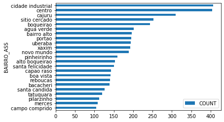

```python
# Resposta:
dfgraph = df.groupby(['BAIRRO_ASS']).size().reset_index(name = 'COUNT')
dfgraph = dfgraph.sort_values('COUNT')
dfgraph = dfgraph[dfgraph['COUNT'] > 100]
dfgraph.plot.barh(x='BAIRRO_ASS', y='COUNT')
```

O problema de considerar apenas o total de reclamações é que não estamos considerando a população dos bairros. Então o ideal é calcular a *taxa* de reclamações, ou seja, o número de reclamações por habitante do bairro.

- Crie um novo DataFrame a partir dos dados do arquivo `../data/dados_bairros.csv`.
- Converta os nomes dos bairros deste DataFrame para caixa-baixo (minúsculo).
- Faça uma junção do DataFrame de totais por bairro com o novo DataFrame.

**Dica:** Para especificar as colunas contendo os valores base para a junção, especifique os parâmetros `left_on` e `right_on` no método `merge`.

```python
# Resposta:
df_bairro = pd.read_csv('../data/dados_bairros.csv', sep=',', encoding='utf-8')
df_bairro["Bairro"] = df_bairro["Bairro"].str.lower()
df_merge_bairro = pd.merge(df_bairro, df_reclamacao_bairro, left_on='Bairro', right_on='BAIRRO_ASS')
df_merge_bairro.head()
```

|  | Bairro | AreaKm2 | Homens | Mulheres | Total | Domicilios | RendimentoDom | COUNT |
| --- | --- | --- | --- | --- | --- | --- | --- | --- |
| 0 | lamenha pequena | 3,4 | 353 | 348 | 701 | 188 | 665,99 | 1 |
| 1 | xaxim | 8,92 | 26747 | 27944 | 54691 | 15482 | 1211,6 | 166 |
| 2 | riviera | 2,36 | 100 | 103 | 203 | 62 | 423,13 | 1 |
| 3 | sao miguel | 7 | 2512 | 2399 | 4911 | 1247 | 409,43 | 2 |
| 4 | campo de santana | 21,57 | 3696 | 3639 | 7335 | 1961 | 564,95 | 52 |

Crie uma nova coluna chamada *taxa* contendo o resultado da divisão da coluna de contagem de reclamações pela coluna de total de habitantes.

```python
# Resposta:
df_merge_bairro["TAXA"] = df_merge_bairro["COUNT"] / df_merge_bairro["Total"]
df_merge_bairro
```

|  | Bairro | AreaKm2 | Homens | Mulheres | Total | Domicilios | RendimentoDom | COUNT | TAXA |
| --- | --- | --- | --- | --- | --- | --- | --- | --- | --- |
| 0 | lamenha pequena | 3,4 | 353 | 348 | 701 | 188 | 665,99 | 1 | 0.001427 |
| 1 | xaxim | 8,92 | 26747 | 27944 | 54691 | 15482 | 1211,6 | 166 | 0.003035 |
| 2 | riviera | 2,36 | 100 | 103 | 203 | 62 | 423,13 | 1 | 0.004926 |
| 3 | sao miguel | 7 | 2512 | 2399 | 4911 | 1247 | 409,43 | 2 | 0.000407 |
| 4 | campo de santana | 21,57 | 3696 | 3639 | 7335 | 1961 | 564,95 | 52 | 0.007089 |
| 5 | ganchinho | 11,2 | 3667 | 3658 | 7325 | 1921 | 767,35 | 12 | 0.001638 |
| 6 | tatuquara | 11,23 | 18134 | 18205 | 36339 | 9525 | 462,26 | 92 | 0.002532 |
| 7 | caximba | 8,17 | 1252 | 1223 | 2475 | 631 | 525,34 | 3 | 0.001212 |
| 8 | umbara | 22,47 | 7280 | 7315 | 14595 | 17064 | 908,7 | 35 | 0.002398 |
| 9 | augusta | 8,84 | 1802 | 1815 | 3617 | 995 | 619,54 | 12 | 0.003318 |
| 10 | boqueirao | 14,8 | 33158 | 35337 | 68495 | 19750 | 1413,53 | 214 | 0.003124 |
| 11 | prado velho | 2,43 | 3506 | 3578 | 7084 | 1854 | 766,57 | 14 | 0.001976 |
| 12 | sitio cercado | 11,12 | 50631 | 51779 | 102410 | 27914 | 934,95 | 212 | 0.002070 |
| 13 | cidade industrial | 43,38 | 76942 | 80519 | 157461 | 43494 | 639,09 | 319 | 0.002026 |
| 14 | cachoeira | 3,07 | 3811 | 3927 | 7738 | 2091 | 908,7 | 16 | 0.002068 |
| 15 | pinheirinho | 10,73 | 13358 | 14549 | 27907 | 13839 | 707,3 | 134 | 0.004802 |
| 16 | cajuru | 11,55 | 43727 | 46057 | 89784 | 14301 | 793,75 | 265 | 0.002952 |
| 17 | santa candida | 10,33 | 13504 | 14366 | 27870 | 7937 | 1211,6 | 104 | 0.003732 |
| 18 | fazendinha | 3,72 | 12751 | 13371 | 26122 | 12071 | 833,84 | 88 | 0.003369 |
| 19 | lindoia | 1,18 | 4012 | 4331 | 8343 | 2368 | 809,46 | 28 | 0.003356 |
| 20 | uberaba | 14,09 | 29418 | 30920 | 60338 | 15482 | 952,14 | 156 | 0.002585 |
| 21 | bairro alto | 7,02 | 20244 | 21789 | 42033 | 12071 | 1211,6 | 165 | 0.003925 |
| 22 | capao raso | 5,06 | 16586 | 17790 | 34376 | 10320 | 977,19 | 123 | 0.003578 |
| 23 | barreirinha | 3,73 | 8079 | 8942 | 17021 | 5024 | 1272,18 | 52 | 0.003055 |
| 24 | abranches | 4,32 | 5463 | 5702 | 11165 | 3154 | 1009,67 | 44 | 0.003941 |
| 25 | parolin | 2,25 | 5801 | 6181 | 11982 | 3307 | 1365,48 | 38 | 0.003171 |
| 26 | atuba | 4,27 | 6156 | 6476 | 12632 | 3627 | 1211,6 | 37 | 0.002929 |
| 27 | campo comprido | 8,55 | 10264 | 11374 | 21638 | 6649 | 1216,71 | 85 | 0.003928 |
| 28 | butiatuvinha | 10,58 | 5311 | 5448 | 10759 | 2948 | 1135,7 | 34 | 0.003160 |
| 29 | capao da imbuia | 3,16 | 9933 | 11043 | 20976 | 6209 | 1147,78 | 79 | 0.003766 |
| ... | ... | ... | ... | ... | ... | ... | ... | ... | ... |
| 42 | santa felicidade | 12,27 | 12157 | 13052 | 25209 | 7202 | 1314,67 | 124 | 0.004919 |
| 43 | boa vista | 5,14 | 13677 | 15714 | 29391 | 9212 | 1817,4 | 125 | 0.004253 |
| 44 | santo inacio | 2,72 | 2940 | 3097 | 6037 | 1683 | 1518,26 | 27 | 0.004472 |
| 45 | jardim botanico | 2,77 | 2813 | 3340 | 6153 | 1980 | 1885,75 | 55 | 0.008939 |
| 46 | portao | 5,7 | 19092 | 21643 | 40735 | 13183 | 1722,89 | 151 | 0.003707 |
| 47 | merces | 3,28 | 6315 | 7774 | 14089 | 4681 | 2475,33 | 89 | 0.006317 |
| 48 | vista alegre | 3,69 | 4735 | 5195 | 9930 | 2855 | 2079,83 | 54 | 0.005438 |
| 49 | bom retiro | 1,94 | 2586 | 3047 | 5633 | 1780 | 2132,75 | 27 | 0.004793 |
| 50 | reboucas | 2,98 | 7136 | 8482 | 15618 | 5813 | 2180,47 | 118 | 0.007555 |
| 51 | sao francisco | 1,36 | 2863 | 3572 | 6435 | 2198 | 2309,05 | 75 | 0.011655 |
| 52 | cascatinha | 2,57 | 994 | 1067 | 2061 | 586 | 2198,43 | 8 | 0.003882 |
| 53 | taruma | 4,17 | 3396 | 3649 | 7045 | 2015 | 3029 | 60 | 0.008517 |
| 54 | centro | 3,3 | 13961 | 18662 | 32623 | 14576 | 2221,51 | 318 | 0.009748 |
| 55 | bacacheri | 6,98 | 10762 | 12344 | 23106 | 7107 | 3029 | 114 | 0.004934 |
| 56 | campina do siqueira | 1,69 | 3379 | 3729 | 7108 | 2238 | 1903,78 | 53 | 0.007456 |
| 57 | ahu | 1,84 | 5117 | 6031 | 11148 | 3608 | 2827,81 | 46 | 0.004126 |
| 58 | sao lourenco | 2,26 | 2611 | 2945 | 5556 | 1603 | 2423,2 | 25 | 0.004500 |
| 59 | vila izabel | 1,21 | 4993 | 5956 | 10949 | 751 | 2438,13 | 26 | 0.002375 |
| 60 | cristo rei | 1,46 | 6147 | 7178 | 13325 | 5128 | 2603,13 | 44 | 0.003302 |
| 61 | hugo lange | 1,15 | 1443 | 1724 | 3167 | 1010 | 3119,76 | 16 | 0.005052 |
| 62 | cabral | 2,04 | 5815 | 5905 | 11720 | 3774 | 3914,15 | 28 | 0.002389 |
| 63 | jardim social | 1,89 | 2893 | 3192 | 6085 | 1674 | 4606,6 | 33 | 0.005423 |
| 64 | seminario | 2,13 | 3350 | 4045 | 7395 | 2243 | 3210,65 | 62 | 0.008384 |
| 65 | juveve | 1,23 | 4995 | 6286 | 11281 | 3994 | 3435,48 | 31 | 0.002748 |
| 66 | centro civico | 0,97 | 2029 | 2738 | 4767 | 1958 | 2878,11 | 42 | 0.008811 |
| 67 | agua verde | 4,76 | 22546 | 27320 | 49866 | 17045 | 3332,57 | 169 | 0.003389 |
| 68 | alto da gloria | 0,88 | 2513 | 3075 | 5588 | 2125 | 3263,47 | 72 | 0.012885 |
| 69 | bigorrilho | 3,5 | 12359 | 14768 | 27127 | 9937 | 3792,68 | 49 | 0.001806 |
| 70 | mossungue | 3,38 | 2751 | 2877 | 5628 | 1586 | 2965,09 | 32 | 0.005686 |
| 71 | batel | 1,76 | 5126 | 6652 | 11778 | 3938 | 5120,73 | 81 | 0.006877 |

72 rows × 9 columns

Exiba um gráfico de barras mostrando os bairros de acordo com a taxa de reclamações.

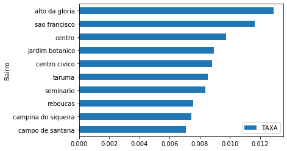

```python
# Resposta:
dfgraph_bairros = df_merge_bairro.sort_values('TAXA', ascending=True)
dfgraph_bairros = dfgraph_bairros[dfgraph_bairros['TAXA'] > 0.007]
dfgraph_bairros.plot.barh(x='Bairro', y='TAXA')
```

## Analisando tendências temporais

Vamos agora identificar os meses com mais reclamações.

- Usando o DataFrame completo (lido a partir do CSV), converta a coluna *DATA* para o tipo `datetime`. Revise o tutorial de Limpeza de Dados se necessário.
- Agrupe as linhas contando as reclamações por mês. Revise o tutorial de Análise Exploratória se necessário.
- Exiba um gráfico de linha com a evolução da contagem.

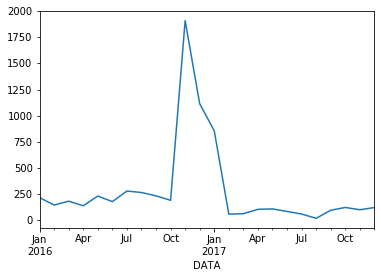

```python
# Resposta:
df['DATA'] = pd.to_datetime(df['DATA'], format='%d/%m/%y')
df.groupby(df.DATA.dt.to_period("M")).size().plot()
```

```python
# Resposta:
```